# G Luku 1 Yksinkertainen korrespondenssianalyysi

Jussi Hirvonen

versio 1.2, tulostettu 2018-10-01

Kommentteja ja versionhallintaa:

- **edit:** oma kommentti, ei varsinaista tekstiä
- kirjastot/paketit ladataan jokaisessa Rmd-dokumentissa
- bib-formaatin viitetietokantaa tullaan kokeilemaan
- kuvasuhde (aspect ratio) edelleen epäselvä juttu! Mutta näyttää PDF-tulosteessa olevan ok.
- Datan käsittely ja hallinta +SPSS:n sallima kolme puuttuvan tiedon koodia saadaan mukaan read_spss-funktion (haven) parametrilla USER_NA = TRUE (mutta tarkistettava!) (25.4.18)
  - faktoreita ei ainakaan toistaiseksi muuteta ordinaaliasteikolle, CA ei tästä välitä
  - pidetään muuttujien ja tiedostojen nimeäminen selkeänä, tarkistetaan aika ajoin
- Taulukot: lisättiin riviprosentti- ja sarakeprosenttitaulut (25.4.18), kuva riviprofiileista puuttu vielä (15.5.2018)
- Datan esittelyssä on turhaa välitulostusta, ja samoin vähän muuallakin. Html on helpompi lukea, kun koodi on oletuksena piilossa
- PDF-tulosteessa koodi pääsääntöisesti näkyy toistaiseksi
- kokeiluja CA-karttojen tulostamiseen (a) suoraan koodilla ja (b) r-grafiikkaikkunasta tallennetun pdf-kuvan avlla. Paras toistaiseksi (a), jätin kokeilu näkyviin. Analyysit R:n grafiikkaikkunassa, jotta asp=1, ja tulkintaa varten voi tallentaa PDF-muodossa.
- rakenteeseen muutoksia (näkyvät sisällysluettelossa), ei erillistä teorialiitettä vaan sopivina annoksina. Lukuun 3 perusasiat, kaavat, määritelmät
- tehdään käsitetaulukko (kirjoittamista varten)
- 20.5.2018 (a) tulkita-osuuteen karttakuvia ja ca-tulokset (b) siistimpi taulukoiden tulostus löytyi (c) kaavaliite laajeni (dispo-haarassa)
- 23.5.2018 lisätään dataan toinen maa-muuttuja maa2, ikäluokkamuuttuja age_cat ja iän ja sukupuolen vuorovaikutusmuuttuja ga.
- 24.5.2018 lisättiin ca-kartta, jossa Saksan ja Belgian ositteet ja summarivit täydentävinä (passiivisina)

**6.8.2018 versio 1.0**

**Siistitään -> 12.8.2018 versio 1.05**

**Kommentit ja korjaukset -> 4.9.2018 versio 1.1**

**puuttuva riviprofiilikuva, siistimmät interaktiomuuttujien koodaukset, ensimmäinen “pinottu taulu” - analyysi -> 19.9.2018 versio 1.2**

**25.9.2018 siistitään datan käsittelyä; ei huomioida puuttuvan tiedon tarkempaa koodausta (read_spss - funktion user_na = TRUE asetus)**

**1.10.2018** Versio 1.2

Uusi jakso yksinkertaisen CA:n laajennuksille, joissa otetaan analyysiin useampia muuttujia “pinoamalla” ja/tai yhdistämällä taulkoita. Tässä jaksossa otetaan myös käyttöön isompi aineisto (enemmän maita ja muuttujia). Siisti koodipätkä täydentävien muuttujien lisäämiseen.

**Muistilista:**

1. Taulukot ja kuvat luvusta 2. alkaen eivät ole “bookdown-muodossa”. CA-tulokset on tulostettu Bookdown-demo - dokumentissa. Ominaisarvojen taulukko keskeneräinen, samoin “scree plot” kuvana puuttuu.
2. Osa kuvista (esim. profiilikuva) pitää varmaan tulostaa pdf-muodossa ja ottaa capaper-dokkariin include_graphics - funktiolla.
3. Puuttuvia tai mahdollisesti lisättäviä taulukoita (nämä saa ca-funktion tuloksista suoraan)
- khii2 - etäisyydet riveille ja sarakkeille?
- massoilla painotetut khii2-etäisyyden keskiarvorivistä/sarakkeesta?
4. Kuvissa vielä hiottavaa, pdf-kuvia lisäilty img-hakemistoon.

**V** MG & Blasius, “vihreä kirja”: contirbutions to inertia

# 1 Data

**edit** tässä luvussa on paljon siistittävää, mutta data on ok. (13.5.2018). **edit** capaper - dokumentissa parempi uusi jäsentely (4.9.2018) **edit** ISSP-datan perustietoa dokumentissa ISSP_data1.docx (4.9.2018) **edit** koodilohkoja ei vielä siistitä, eikä nimetä capaper-vaatimusten mukaan.

**edit 24.9.18 Poistettiin turhaa, uusi versio tiedostosta (G1_1_data1.Rmd -> G1_1_data2.Rmd).**

## 1.1 Luvun 1 tavoitteet

**Datan esittely ja kuvailut - tämä luku täysin uusiksi (24.9.18)**

2012 data, muuttujaluokat (subst, demog.). Lisäksi maakohtaisia juttuja.

1. Eksploratiivinen ja graafinen menetelmä tarvitseen aineiston, hankalaa esitellä jollain synteettisellä esimerkkiaineistolla. **edit** Eksp&graaf menetelmät määriteltävä johdantoluvussa. Esimerkkiaineistoja (synteettisiä kuten smoke, myös muita) on mm. ca - paketissa.
2. CA (ja MCA) sopivat isojen moniulotteisten ja mutkikkaiden aineistojen analyysiin, siksi iso aineisto. Samalla analyysiä voi laajentaa moneen suuntaan. **V** Benzecri:“kun data menee miljoonaan suuntaan”.
3. Aineiston esittely, laajan kyselytutkimusaineiston tyypilliset ominaisuudet
4. Laadukkaan ja hyvin dokumentoidun aineiston edut
5. Tärkeä rajaus: CA sopii ja sitä on käytetty myös hyvin toisen tyyppisiin aineistoihin (ekologia ja biologia, arkeologia, kielen tutkimus)

## 1.2 Perhe ja muuttuvat sukupuoliroolit - ISSP:n kyselytutkimuksen data 2012

Hieman historiaa datasta, sosiaalisesti määräytyneen sukupuoliroolit (gender) tutkimusaiheena neljässä kansainvälisessä kyselytutkimuksessa.

www.issp.org, www.gesis.org : mistä on kysymys data ja dokumentaatio (selattavissa): zacat.gesis.org

**edit** tässä järkevä viite ISSP - dataan ISSP Research Group (2016): International Social Survey Programme: Family and Changing Gender Roles IV - ISSP 2012. GESIS Data Archive, Cologne. ZA5900 Data file Version 4.0.0, doi:10.4232/1.12661 **tämä doi-linkki ei toimi**

**Linkitys on hankalaa**

- monta portaalia, joista pääsee monien organisaationimien taakse
- tästä lyhyt selostus
- tärkeimmät linkit ISSP-tutkimuksen “kotisivu” ja selkeä **muuttujakuvaukset ja muut tiedot**
- käytännössä linkittäminen “syvälle” johonkin sivustoon tai www-palveluun ei ole järkevää, parempi antaa selkeät viitetiedot ja tiedot organisaatioista. Ne kyllä säilyvät, tai jäljille pääsee.

[Aineistot](https://dbk.gesis.org/dbksearch/sdesc2.asp?no=5900&db=e) 2012 **toimii - ja viitetieto tuossa edellä!** **V**

[Muuttujakuvaukset ja muut tiedot](http://zacat.gesis.org/webview/index.jsp?object=http://zacat.gesis.org/obj/fStudy/ZA5900) **OK - täältä löytyy oikeastaan kaikki!**

[Data ja dokumentit](https://dbk.gesis.org/dbksearch/sdesc2.asp?no=5900&db=e) **vie vain aineiston dokumentoinnin etusivulle**

[Suomenkielinen lomake (ZA5900_q_fi-fi.pdf)](https://dbk.gesis.org/dbksearch/sdesc2.asp?no=5900&db=e&doi=10.4232/1.12661) **vie vain aineiston dokumentoinnin etusivulle**

[Käyttöehdot:](https://www.gesis.org/en/services/data-analysis/more-data-to-analyze/data-archive-service/) **GESIS-palvelun datan yleiset käyttöehdot, viittauskäytännöt**

[Tiedonkeruumenetelmä ja otoskoko:](https://dbk.gesis.org/dbksearch/sdesc2.asp?no=5900&db=e&doi=10.4232/1.12661) ** Viimeisin Portugali 29.06.2014 - 31.01.2015, ensimmäinen Bulgaria 16.08.2011 - 20.09.2011. Suurin osa muista 2012-13, kuten Suomi (21.09.2012 - 07.12.2012 ).

**Vie tutkimushankkeen “kotisivulle”** ZA5900: International Social Survey Programme: Family and Changing Gender Roles IV - ISSP 2012

Havaintojen lukumäärät voi tarkistaa [täältä](http://zacat.gesis.org/webview/index.jsp?object=http://zacat.gesis.org/obj/fStudy/ZA5900) . **Vie aineiston dokumentointisivustoon, jossa helppo navigoida** zacat.gesis.org.

edit: aineiston kuvailua voi ja kannattaakin jatkossa tarkentaa, ja laittaa se liitteeksi(?- tuskinpa). Dokumentointi on hyvin tarkka, tiedot löytyvät haastattelumenetelmista (parerilomake, tietokoneavusteinen haastattelu, jne), maakohtaisten taustamuuttujien harmonisoinnista maittain, otantamenetelmistä jne. Esittelen vain aineiston tärkeimmät rajaukset.

## 1.3 Aineiston rajaaminen

**zxy** Aineiston kuvailu omana osanaan (7.8.2018). **zxy** capaper - dokumentissa uusi jäsentely (4.9.2018)

Ainestossa (jatkossa ISSP2012) on kyselytutkimukseen tulokset 41 maasta. Lisäksi aineistossa on runsaasti demografisia ja muita taustatietoja. R-koodista selviää käytetty versio (SPSS-tiedoston nimi) ja rajauksessa käytetyt muuttujat.

**Rajaukset**

**zxy** Aineiston luonne: maakohtaisesti eri tavoin kerätty data, jossa pyritään yhtenäisiin käytäntöihin ja tietosisältöihin. Silti myös substanssikysymyksissä eroja, isoja ja pienempiä. Näin vain on, en pohdi miksi. Ei ole mitenkään ainutlaatuista. Aineiston editoinnissa ja tiedonkeruun suunnittelussa on nähty paljon vaivaa vertailukelpoisuuden vuoksi. Tästä esimerkkejä, esim. “mitä puoluetta äänestit”.

**1. Eurooppa ja samankaltaiset maat (28)**

Bulgaria, Czech Republic, Denmark, Finnland,France, Germany, Great Britain, Ireland, Latvia, Lithuania, Norway, Poland, Sweden, Slovakia Slovenia, Spain, Switzerland, Australia, Austria, Canada, Croatia, Iceland, Russia, United States, Belgium, Hungary, Netherlands, Portugal

Pois jätettiin 13: Argentiina,Turkki, Venezuela, Etelä-Afrikka, Korea, Intia, Kiina, Taiwan, Filippiinit, Meksiko, Israel, Japani, Chile.

**2. Maat joissa varsinaisissa tutkimuskysymyksissä on käytetty poikkeavia luokitituksia tms.**

**zxy** Näitä poikkeuksia on paljon… pitänee perustella, tai vähentää maita. Valitaan muuttujat ja tarkistetaan, ikävä kyllä!

Esimerkiksi Espanjan datassa on jätetty pois neutraali “en samaa enkä eri mieltä” - vaihtoehto, Unkarin datassa on omia versioita kysymyksistä jne. Espanja jätetään ainakin aluksi pois vertailukelpoisuuden vuoksi, Unkari ehkä myös. Unkari voi silti olla mukana yksinkertaisessa esimerkissä, jatkosta pois?

**3. kaikki havainnot, joissa on puuttuvia tietoja.** “listwise deletion”

Tämä rajaus on kyselytutkimuksessa ankara, tai oikeastaan kelvoton. Oikea menettely olisi imputoida jollain menetelmällä puuttuvat tiedot, mutta rajaan otantatutkimuksen menetelmät tutkielman ulkopuolelle (aiheesta löytyy artikkeleita…).Yksittäisten vastausten puuttuminen eli erävastauskato ohitetaan aluksi, mutta siihen palataan. Korrespondenssianalyysiin on helppo ottaa mukaan myös puuttuvat tiedot, sillä data on luokitteluasteikon dataa. Yksikkövastauskato eli otokseen poimitut joita ei ole tavoitettu ollenkaan on kansallisen tason ongelma, joka on ratkaistu vaihtelevin tavoin. Tiedot löytyvät aineiston dokumentaatiosta. Aineistossa on myös mukana painomuuttujat, mutta ne soveltuvat vain jokaisen maan omaan aineistoon.

**zxy** Tärkein rajaus esimerkkianalyyseissä, ja voidaan esitellä CA:n käyttö puuttuvien vastausten analysoinnissa (Likert-asteikkolla).

**edit:** Tähän täsmennetään miten puuttuvia tietoja käsitellään.

4. Datan hallinta **liittyy reproducible research- periaatteeseen**

Aineistoa käsitellään ja muokataan niin, että jokaisen analyysin voi mahdollisman yksinkertaisesti toistaa suoraan alkuperäisestä datasta.

Aineiston muokkauksen (muuttujien ja havaintojen valikointi, muunnokset ja uusien muuttujien luonti jne.) dokumentoidaan r-koodiin.

Tiedostojen nimeäminen: alkuperäinen data (spss-formaatti), luettuna R-ohjelmaan ISSP2012.dat. Tästä lähdetää; yleensä seuraavaksi valitaan maat, sitten muuttujat.

**edit** kuva tai taulukko rajaamisista? Vai voiko dokumentoida R-koodiin kommentteina?

**zxy** R-koodiin jätetään myös tarkistuksia yms. joita ei raportoida tässä, samoin niiden tuloksia. Voiko R-koodi olla fingelskaa?

```r
# kolme maa-muuttujaa datassa. V3 erottelee joidenkin maiden alueita, V4 on koko maan
#two country code variables based on the ISO Code 3166. One identifies
#countries as a whole, the other one possible subsamples, such as East and West Germany. The cross
#tabulations shown in this Variable Report are based on a third, alphanumerical country code variable,
#which also identifies subsamples."
#V3 - Country/ Sample ISO 3166 Code (see V4 for codes for whole nation states)
# V3 erot valituissa maissa
# 5601 BE-FLA-Belgium/ Flanders
# 5602 BE-WAL-Belgium/ Wallonia
# 5603 BE-BRU-Belgium/ Brussels
# 27601 DE-W-Germany-West
# 27602 DE-E-Germany-East
# 62001 PT-Portugal 2012: first fieldwork round (main sample)
# 62002 PT-Portugal 2012: second fieldwork round (complementary sample)
# Myös tämä on erikoinen, näyttää olevan vakio kun V4 = 826:
# 82601 GB-GBN-Great Britain
# Portugalissa ainestoa täydennettiin, koska siinä oli puutteita. Jako ei siis ole oleellinen,
# mutta muuut ovat. Tähdellä merkityt maat valitaan johdattelevaan esimerkkiin.
# Maat:
# 36 AU-Australia
# 40 AT-Austria
# 56 BE-Belgium*
# 100 BG-Bulgaria*
# 124 CA-Canada
# 191 HR-Croatia
# 203 CZ-Czech Republic
# 208 DK-Denmark*
# 246 FI-Finland*
# 250 FR-France
# 276 DE-Germany*
# 348 HU-Hungary*
# 352 IS-Iceland
# 372 IE-Ireland
# 428 LV-Latvia
# 440 LT-Lithuania
# 528 NL-Netherlands
# 578 NO-Norway
# 616 PL-Poland
# 620 PT-Portugal
# 643 RU-Russia
# 703 SK-Slovakia
# 705 SI-Slovenia
# 752 SE-Sweden
# 756 CH-Switzerland
# 826 GB-Great Britain and/or United Kingdom
# 840 US-United States
#
# Belgian ja Saksan alueet:
#  V3
#  5601     BE-FLA-Belgium/ Flanders
#  5602     BE-WAL-Belgium/ Wallonia
#  5603     BE-BRU-Belgium/ Brussels
# 27601     DE-W-Germany-West
# 27602     DE-E-Germany-East

#valittavien maiden kolminumeroinen ISO 3166 - koodi vektoriin
# Espjana pois (724 ES-Spain)  - Unkari (348) toistaiseksi mukana, mutta joissain kysymyksissä myös Unkarilla on poikkeavia #vastausvaihtoehtoja(HU_V18, HU_V19,HU_V20). Jos näitä muuttujia käytetään, on Unkarikin parempi jättää aineistosta pois.

incl_countries <- c(36, 40, 56,100, 124, 191, 203, 208, 246, 250, 276, 348, 352, 372, 428, 440,
                    528, 578, 616, 620, 643, 703, 705, 752, 756, 826, 840)
ISSP2012.data <- read_spss("data/ZA5900_v4-0-0.sav")
str(ISSP2012.data)
```

[output not shown]

[output cut: 464 more lines]

[output not shown]

```r
#
# lisäys 25.4.2018 user_na / 25.9.2018 jäteään pois. Tietoa ei käytetä, ja koodauksissa on myös
# eroja maiden välillä.
# Muutetaan R-datatiedossa ordinaali- ja nominaaliasteikon muuttuja haven-paketin as_factor - funktiolla faktoreiksi.
# R:n faktorityypin muuttujille voidaan tarvittaessa määritellä järjestys, toistaiseksi niin ei tehdä (25.9.2018)
# "If TRUE variables with user defined missing will be read into labelled_spss objects.
# If FALSE, the default, user-defined missings will be converted to NA"
# https://www.rdocumentation.org/packages/haven/versions/1.1.0/topics/read_spss
#
#
#
#str(ISSP2012.data) #61754 obs. of  420 variables
ISSP2012jh1.data <- filter(ISSP2012.data, V4 %in% incl_countries)
#length((ISSP2012jh1.data))
names(ISSP2012jh1.data)
```

```
##   [1] "V1"       "V2"       "DOI"      "V3"       "V4"       "C_ALPHAN"
##   [7] "V5"       "ES_V5"    "V6"       "ES_V6"    "V7"       "ES_V7"
##  [13] "V8"       "ES_V8"    "V9"       "ES_V9"    "V10"      "ES_V10"
##  [19] "V11"      "ES_V11"   "V12"      "V13"      "V14"      "ES_V14"
##  [25] "V15"      "ES_V15"   "V16"      "ES_V16"   "V17"      "ES_V17"
##  [31] "V18"      "ES_V18"   "HU_V18"   "V19"      "ES_V19"   "HU_V19"
##  [37] "V20"      "ES_V20"   "HU_V20"   "V21"      "V22"      "ES_V22"
##  [43] "V23"      "ES_V23"   "V24"      "ES_V24"   "V25"      "ES_V25"
##  [49] "V26"      "ES_V26"   "V27"      "ES_V27"   "V28"      "V29"
##  [55] "V30"      "V31"      "V32"      "V33"      "V34"      "V35"
##  [61] "V36"      "V37"      "V38"      "V39"      "V40"      "V41"
##  [67] "V42"      "V43"      "V44"      "V45"      "V46"      "V47"
##  [73] "V48"      "V49"      "V50"      "V51"      "V52"      "V53"
##  [79] "V54"      "V55"      "V56"      "V57"      "V58"      "V59"
##  [85] "V60"      "V61"      "V62"      "V63"      "V64"      "V65"
```

[output cut: 55 more lines]

```r
#str(ISSP2012jh1.data) #37816 obs. of  420 variables jos Espanja mukana, nyt 35221 obs. of  420 variables
#str(ISSP2012jh1.data)
#Maakohtaiset muuttujat on aineistossa erotelut maatunnus-etuliitteellä (esimerkiksi ES_V7). Nämä muuttujat voi jättää pois, #niiden arvo muilla mailla on "NA" (puuttuva tieto)
#summary(ISSP2012jh1.data$ES_V5)
#
#V18$label
#attr(ISSP2012jh1.data$V6,'labels')
#attr(ISSP2012jh1.data$ES_V6,'labels')
```

**edit** * tarpeetonta ja vähän sekavaa, mutta jääköön toistaiseksi.**

**Siistitään, uusi versio tiedostosta (G1_1_data1.Rmd -> G1_1_data2.Rmd)** **ISSP2012jh1.data - 27 maata. Turhia muuttujia (=kaikki), mutta valitaan tästä aina analyyseissä käytettävät muuttujat**

##Puuttuvat tiedot

**zxy** Perusasiat havaintojen puuttellisuudesta kyselytutkimusissa. Yksikkövastauskato (unit non-response), eräsvastauskato (item non-response). Mitä on raportoitava, kun käytetään valmista aineistoa? Erävastauskato on silti ongelma, vaihtelee kysymyksittäin, vaikka se ei kovin suuri olekaan.

Yksikkövastauskato on (onko?) otettu huomioon, kun kyselyn toteuttaja on editoinut ja tarkastanut datan. **Viittet**

Aineistossa on tarkempi kolmen luokan koodaus puuttuvalle tiedolle, mutta toistaiseksi sitä ei käytetä.

**zxy Miten puuttuneisuus kannattaa kuvailla? Löytyy dokumentaatiosta!**

1. Kuvaillaan vain mukaanotettavan datan osalta
- subst
- demog
- muut?

**edit** miten taulukko siististi bookdownissa?

**zxy** Unkarilla poikkeavat vastausvaihtoehdot kysymyksessä Q5, jos sitä ei käytetä niin olkoon HU mukana!

Muiden kuin Espanjan vastaukset kysymykseen V6 jakautuvat näin:

```r
temp2 <- ISSP2012jh1.data %>% filter(!(V4 == 724)) # Espanja pois

str(temp2)
```

[output not shown]

[output cut: 464 more lines]

[output not shown]

```r
temp2$V5 <- factor(temp2$V6 )
temp2$maa <-  factor(temp2$C_ALPHAN)
#summary(temp2)
#str(taulu1)
taulu1 <- temp2 %>% tableX(V6,maa,type = "count")
taulu1a <- taulu1[ ,1:14]
knitr::kable(taulu1a,digits = 2, booktabs = TRUE,
             caption = "Kysymyksen V6 vastaukset maittain")
```

Kysymyksen V6 vastaukset maittain

|  | AT | AU | BE | BG | CA | CH | CZ | DE | DK | FI | FR | GB-GBN | HR | HU |
| --- | --- | --- | --- | --- | --- | --- | --- | --- | --- | --- | --- | --- | --- | --- |
| 1 | 218 | 82 | 193 | 118 | 51 | 89 | 174 | 165 | 70 | 47 | 256 | 37 | 75 | 219 |
| 2 | 447 | 405 | 454 | 395 | 215 | 431 | 392 | 376 | 238 | 188 | 551 | 247 | 265 | 288 |
| 3 | 171 | 285 | 440 | 205 | 181 | 222 | 403 | 199 | 152 | 149 | 424 | 208 | 190 | 225 |
| 4 | 205 | 568 | 554 | 190 | 317 | 365 | 415 | 538 | 232 | 423 | 469 | 331 | 327 | 190 |
| 5 | 98 | 215 | 381 | 13 | 194 | 112 | 355 | 441 | 696 | 303 | 624 | 105 | 133 | 75 |
| Missing | 43 | 57 | 180 | 82 | 14 | 18 | 65 | 47 | 15 | 61 | 85 | 22 | 10 | 15 |
| Total | 1182 | 1612 | 2202 | 1003 | 972 | 1237 | 1804 | 1766 | 1403 | 1171 | 2409 | 950 | 1000 | 1012 |

```r
taulu1b <- taulu1[ ,15:28]
knitr::kable(taulu1b,digits = 2, booktabs = TRUE,
             caption = "Kysymyksen V6 vastaukset maittain")
```

Kysymyksen V6 vastaukset maittain

|  | IE | IS | LT | LV | NL | NO | PL | PT | RU | SE | SI | SK | US | Total |
| --- | --- | --- | --- | --- | --- | --- | --- | --- | --- | --- | --- | --- | --- | --- |
| 1 | 56 | 13 | 50 | 188 | 59 | 23 | 110 | 73 | 244 | 29 | 39 | 117 | 86 | 2881 |
| 2 | 250 | 138 | 438 | 395 | 296 | 186 | 395 | 495 | 542 | 124 | 272 | 246 | 350 | 9019 |
| 3 | 197 | 186 | 396 | 156 | 242 | 226 | 155 | 157 | 360 | 219 | 200 | 229 | 652 | 6829 |
| 4 | 478 | 552 | 220 | 209 | 445 | 579 | 365 | 215 | 254 | 276 | 365 | 298 | 196 | 9576 |
| 5 | 197 | 271 | 22 | 38 | 196 | 365 | 64 | 52 | 42 | 354 | 131 | 198 | 0 | 5675 |
| Missing | 37 | 12 | 61 | 14 | 77 | 65 | 26 | 9 | 83 | 58 | 27 | 40 | 18 | 1241 |
| Total | 1215 | 1172 | 1187 | 1000 | 1315 | 1444 | 1115 | 1001 | 1525 | 1060 | 1034 | 1128 | 1302 | 35221 |

Koko aineistossa (valitut 27 maata) kysymyksen V6 vastauksista puuttuvia tietoja on 3,5 prosenttia (1241/35221).

**zxy 24.9.2018 Tällaisia eroja löytyy, ohitetaan mutta mainitaan. Pitäisikö (a) pudottaa kaikki joilla puuttuvia joissain muuttujissa vai (b) yhdistää NA ja eos?**

Tarkastellaan aineston puuttuvia havaintoja hieman tarkemmin. Puuttuvat tiedot on koodattu aineistoon näin: 0: Not applicapble (NAP), Not available (NAV) 7: (97,997, 9997,…): Refused 8: (98, 998, 9998,…): Don’t know 9: (99, 999, 9999,…): No answer

NAP ja NAV määritellään

"GESIS adds ‘Not applicable’(NAP) codes for questions that have filters. NAP indicates that only a subsample and not all of respondents were asked. Also in the case of country spesific variables, all the other countries are coded NAP.

GESIS adds ‘Not available’ for variables, which in singe countries may not have been conducted for whatever reason."

**zxy** **Miten nämä tarkemmat tiedot (7, 8, 9 saadaan näkyviin?)**

**EDIT:** Puuttuneisuuden lyhyttä kuvailua, ja rajausten vaikutus havaintojen lukumäärään muutamaan taulukkoon. Voi siirtää liitteisiin (25.4.2018)

Lyhyt taulukko, jossa maittain ja muuttujittain puuttuneiden tietojen osuus.

## 1.4 Substanssimuuttujat, taustamuuttujat, muut

**zxy** muuttujien kuvaukset.

**zxy** tässä myös maakohtaisen poikkeavat kysymykset, joita riittää aika lailla.

**zxy** HUOM! Dataa ei ole kerätty vain kansainvälisiin vertailuhihin! Sitä voi ja ehkä pitäisikin analysoida maa kerrallaan, ja vertailla näitä tuloksia. (**#V** Blasiuksen artikkeli, jossa arvioidaan yhden ISSP-tutkimuksen vertailukelpoisuutta. Kysymykset eivät kovin hyvin näytä toimivan samalla tavalla eri maissa.)

**zxy** Myös maakohtaiset erot, ja niiden vaikutus aineiston rajaamiseen

**zxy** yksi kappale: Aineitoa on harmonisoitu, kysymyksiä hiottu, vertailukelpoisuuteen on pontevasti pyritty. Silti eroja löytyy, osa ymmärrettäviä (lisäkysymykset jne) ja osa ei (Espanja!). Tällaista on kansainvälisen kyselytutkimuksen data.

**edit:** **nämä merkinnät ovat muistiinpanoja, kun tarkemmin luin muuttujadokumenttia.** Kysymyksissä on vaihtelua, ja tavallaan niin pitääkin olla kansainvälisessä kyselytutkimuksessa. Vastaajien on ymmärrettävä kysymyksen suurinpiirtein samalla tavalla. Kaikki on tarkasti dokumentoitu.

**edit:** täsmennettävä, periaatteessa vastaukset on harmonisoitu. Joistain maista joku tieto puuttuu, jos sitä ei ole kysytty. Joissain tapauksissa kysymysten vaihtoehdot poikkeavat standardista.

Aineistossa on ns. substanssimuuttujia 63 (V5 - V67). Suurin osa on kerätty jollain haastattelumenetelmällä, ja yleisin vastausvaihtoehto on viiden arvon Likert-skaala (1 = täysin samaa mieltä, samaa mieltä, en samaa enkä eri mieltä, eri mieltä, täysin eri mieltä =5). Eri maiden lomakkeissa on vaihtelua puuttuviksi tiedoiksi koodattujen muiden vastausten välillä.

**Esimerkikisi Suomen lomakkeessa on kuudes vaihtoehto “en osaa sanoa”, ja lisäksi on koodattu vastaamisesta kieltäytyminen tai muuten puuttuva tieto.** Ensimmäisessä aineiston rajauksessa nämä kaikki jätetään pois, käytetään “yleistä” puuttuvan tiedon määritelmää (eli joku noista em.).

Espanjan lisäksi Unkarin osatutkimuksessa kysymyksen V18 V19 V20 vastausvaihtoehdot ovat poikkeavat siten, että keskimmäinen neutraali vaihtoehto on jätetty pois (em.dok, s. 48).

Islannissa kysymykseen V28 (Consider a couple who both work full-time and now have a new born child. One of them stops working for some time to care for their child. Do you think there should be paid leave available and, if so, for how long?) on tarjolla oma vastausvaihtoehto ((97) “Yes, but don’t know how many months”). Kysymyseen "V29 - Q9 Paid leave: Who should pay ja V30(Paid leave: How to divide between parents) Bulgarian kysely on poikkeava (0 NAP (code 0,98 in V28), s. 91).

Hollannin vastausvaihtoehdoissa kysymykseen V35 (Elderly people: Provider of domestic help) on oma variantti “5 Empoyers”, jonka kuitenkin on valinnut vain 6 vastajaa (0,5 %).

V39, V40, V41, V42, V43, V44, V45, V46, V47, V48, V50, V51, V52, V53, V54: paljon poikkeamia, aika vaikeaselkoisia kysymyksiä. Näitä ehkä pitää tutkailla… V55 (Life in general: How happy on the whole) ok.

V56-57 poikkeamia, V58 (Health status) ok V59 “ketjutettu kysymys”, samoin V60-V64. s. 174 - puolison koulutus…

** edit ** Nämä muistiinpanot on tehty, kun upottiin dokumentointiin aika syvälle… Kätevimmin selviää, kun katsoo mistä muuttujista on datassa “maaversio” (esim. ES_V6).

# 2 Yksinkertainen korrespondenssianalyysi - kahden luokittelumuuttujan taulukko

**jäsennystä**

Tässä esitellään yksinkertainen esimerkki, yksi kysymys (esim. V6) ja muutamia maita ristiintaulukoituna. Johdatteluna aiheeseen esitellään ca-käsitteet profiili, massa ja reunajakauma. Havainnollistetaan rivi- ja sarakeprofiilien vertailua vastaaviin keskiarvoprofiileihin.

Riippumattomuushypoteesi ja $\chi^2$ - riippumattomuustesti (pieni huomautus - on monta tapaa testata taulukon riippuvuuksia). Riippumattomuushypoteesi ehdollisena todennäköisyytenä reunajakauman suhteen. **zxy** Tämä puuttuu kaavoista!

**zxy**

**Tarvitaanko käsitteellistä täsmentämistä, tai selkiinnyttämistä?**

1. Taulukon käsite

Erityisesti CA, jossa “ranskalaisella terminologialla” käsitellään yksilöiden tai havaintoyksiköiden pilveä ja muuttujien pilvelä (nominaaliasteikko). Taulukot saadaan yksinkertaisen CA:n tapauksessa aggregoimalla “cloud of individuals”. **#V** MOOC, LeReoux

2. Kontingenssitaulu (kts. viite, jossa ohje “yhteys aina riviä pitkin”), frekvenssitaulu, ristiintaulukointi
- dataa valitaan, aggregoidaan, ryhmitellään. Aktiivisia valintoja. Blasius emt. “data ei löydy kadulta”, ja vaikka siitä ei ole epäilystäkään ISSP-datan tapauksessa, niin siitäkin jatketaan eteenpäin.
3. Peruskäsitteiden yksinkertaisessa esityksessä tärkein lähde MG:n CAiP **#V** Siellä tästäkin on sananen: substanssiero usein on.
4. CA:ssa hämäävä juttu (Blasius, “vizualisation - verkkokirja”) rivien ja sarakkeiden **tekninen** symmetria.

$\chi^2$ - etäisyys, yhteys hajontaan eli inertiaan ca-terminologiassa.

Dimensioiden vähentämisen idea (“the essence”), joka ei pienessä taulossa ole ihan ilmeinen. Toinen tavoite on visualisointi, yleensä kaksiulotteisena kuvana (karttana).

Yksinkertainen korrespondenssianalyysi on kahden luokitteluasteikon muuttujan riippuvuuksien geometrista analyysiä. Lähtökohta on kahden muuttujan ristiintaulukointi, alkuperäinen data voi olla muillakin asteikoilla mitattua. Menetelmän ydin on tarkastella molempien muuttujien – taulukon rivien ja sarakkeiden – riippuvuuksia kaksiulotteisena kuvana. Kuvaa kutsutaan myös kartaksi, ja tulkinnan ensimmäinen askel on kartan “koordinaatiston” tulkinta. Kaikki etäisyydet kuvassa ovat suhteellisia, vain rivi- ja sarakepisteiden etäisyydet kuvan origosta voidaan tulkita tarkasti. Koordinaatiston tulkinta aloitetaan “katsomalla mitä on oikealla ja vasemmalla, ja mitä on ylhäällä ja alhaalla” (viite LeRoux et.al, Bezecri-sitaatti). Vaikka pisteiden etäisyyksiä edes rivi- ja sarakepisteiden välillä ei voi tarkkaan tulkita (approksimaatioita), projektiossa kaukana toisistaan olevat pisteet ovat kaukana toisistaan myös alkuperäisessä “pistepilvessä”.

**Vanha lista:**

1. Ensimmäinen taulukko: profiilit, massat, keskiarvoprofiilit, khii2 - riippumattomuustesti ja etäisyysmitta
2. Hyvin tiivis esitys CA:n perusideasta, mutta ilman aivan simppeleitä kolmiulotteisia kuvia (niitä on jo)
3. Ensimmäinen symmetrinen kartta, perustulkinta (mitä kuvasta voidaan sanoa, mitä ei)
4. Lyhyt viittaus graafisen esityksen tulkintapulmiin, jotka eivät ole kovin pahoja. Niihin palataan kaksoiskuva-jaksossa.
5. Tulkinnan syventäminen - CA-käsitteiden tarkempi esittely

Haaste: käsitteet ja niiden suhteet ovat abstraktien matemaattisten rakenteiden tuloksia (barycentric, sentroidi), ja ne pitää jotenkin johdonmukaisesti pala kerrallaan tuoda esimerkkien kautta tekstiin. Käsittteistä oma Rmd (ja Excel jos osoittautuu kätevämmäksi), kaavaliite Dispo-repossa ja myös Rmd-muodossa. **edit** Kaavaliitteessä pieniä eroja, ja tekstiä on LateX-versiossa enemmän.

Keskeiset lähteet: MG:n “Correspondence analysis in practice”, “Biplots in practice”, HY:n 2017 kurssin materiaali ja laskuharjoitukset. Näissä kaikissa on käytetty samaa dataa esimerkeissä. Lisäksi perusasioiden esittelyssä MG & Blasius artikkelikokoelma (“vihreä kirja”), joissain kohdin Lerouxin ja Romanetin teos.

**Ensimmäinen symmetrinen kartta**

Tulkinnat ja yksinkertaisimmat perussäännöt. Dimensiot ja kuinka paljon alkuperäisen taulukon inertiaa saadaan esitettyä kartalla. Sitten asian ydin, akseleiden tulkinta (“mitä on oikealla ja vasemmalla”). Jos pisteet ovat alkuperäisessä “pilvessä” kaukana toisistaan, ne ovat sitä myös projektiossa. Kartta, mutta etäisyyksillä ei suoraa tulkintaa paitsi eteisyyksinllä origoon. Rivipisteiden suhteelliset etäisyydet, samoin sarakepisteidet.

Varoitus virhetulkinnasta: ryhmien tunnistaminen rivi, jopa rivi- ja sarakepisteistä koostuvien ryhmien. **zxy** Ja silti tavallaan voi. Sarake- ja rivipisteiden etäisyyksille ei ole suoraa tulkintaa, mutta on “vetovoima” (attraktio) ja “työntövoima” (repulsio). Jos profiilissa sarakemuuttujan osuus on suuri (siis suurempi kuin keskiarvopisteessä, suhteellinen ero), se “ajautuu” lähelle sarekepistettä. MG: “loose ends” - paperi, symmetrinen kuva eräs suurin sekaannuksen lähde. Tätä koitetaan selventää myös MG:n JASA-artikkelissa.

**zxy** termi korrespondenssi: “neglected multivariate method” - paperissa käännetty näin englanniksi ransk. termi,tätä itsekin nykyään käyttävät), rivien ja sarakkeiden “correspondence” eli yhteys/“riippuvuus”/vastaavuus tms.

**zxy** . Tarina: valitaan edellisessä luvussa esitetyn pohjalta osa muuttujista, perustellaan miksi työmarkkia-asenteen ovat kiinnostavia, valitaan esimerkkianalyyseihin **yksi** muuttuja ja kuusi maata.

## 2.1 Äiti työssä

**zxy** Perustellaan aineiston valinnan vaiheet. Esimerkiksi otetaan yksi kysymys.

**zxy** Suhde data-lukuun, siellä pitäisi esitellä aineisto sisällöllisesti. Tässä vain valitan esimerkkiä varten yksi kysymys ja kuusi maata.

**zxy** Muuttujien nimeäminen vaikuttaa (a) muuttujien faktorointiin ja (b) kuviin ja taulukoihin.

Aineisto muuttujat V5-V9 ovat vastauksia (1-5 Likert, täysin samaa mieltä - täysin eri mieltä) seuraaviin kysymyksiin (suomenkielinen lomake, kysymys 23):

1. Työssäkäyvä äiti pystyy luomaan lapsiinsa aivan yhtä lämpimän ja turvallisen suhteen kuin äiti, joka ei käy työssä
2. Alle kouluikäinen lapsi todennäköisesti kärsii, jos hänen äitinsä käy työssä
3. Kaiken kaikkiaan perhe-elämä kärsii, kun naisella on kokopäivätyö
4. On hyvä käydä töissä mutta tosiasiassa useimmat naiset haluavat ensisijaisesti kodin ja lapsia
5. Kotirouvana oleminen on aivan yhtä antoisaa kuin ansiotyön tekeminen

**zxy** Tässä koodilohkossa esimerkki helposti toistettavasta tutkimuksesta: alkuperäisestä datasta liikkeelle. user_na = true - jutun voi mainita, ja viitata koodiliitteeseen. Alaviitteeksi, sillä ei analysoida tarkemmin?

**zxy** koodilohkon loppu ehkä tarpeeton, tarkistettava!

```r
# Alkuperäinen data (poistetaan user_na =TRUE 25.9.2018)
ISSP2012.data <- read_spss("data/ZA5900_v4-0-0.sav")
#
# user_na - parametri haven-paketin read_spss - funktiossa:
# "If TRUE variables with user defined missing will be read into labelled_spss objects.
# If FALSE, the default, user-defined missings will be # converted to NA"
# https://www.rdocumentation.org/packages/haven/versions/1.1.0/topics/read_spss
#
# str(ISSP2012.data)
#61754 obs. of  420 variables ja 61754 obs. of  420 variables 25.4.18
#

# Yksi kysymys ja kuusi maata
incl_esim1 <- c(56, 100, 208, 246, 276, 348) #BE,BG,DK,FI,DE,HU)

ISSP2012esim1.dat <- filter(ISSP2012.data, V4 %in% incl_esim1)
#str(ISSP2012esim1.dat) #8557 obs. of  420 variables
#
# mukaan muuttujat, V3 jos halutaan jakaa Saksa ja Belgia
# SEX 1=male, 2=female AGE haastateltava ikä haastatteluhetkellä
#
ISSP2012esim1.dat <- select(ISSP2012esim1.dat, C_ALPHAN, V3,V4, V6, SEX, AGE)

#str(ISSP2012esim1.dat) #8557 obs. of  6 variables
#
```

**zxy** Tehdään aineistoon muutama muutos (eli faktoreiksi, mutta ei järjestystä), jotta sen käsittely on helpompaa.

**zxy** taulukot erotettava omiksi koodilohkoiksi bookdowniin.

```r
# muutetaan muuttujia faktoreiksi
#
# Luokittelumuuttujien tasoille labelit
#
# sp (sukupuoli) m = 1, f = 2
sp_labels <- c("m","f")
# S = täysin samaa mieltä, s = samaa mieltä, ? = ei samaa eikä eri, e = eri mieltä, E = täysin eri mieltä
vastaus_labels <- c("S","s","?","e","E")

# Faktoreiksi
ISSP2012esim1.dat$maa <- factor(ISSP2012esim1.dat$C_ALPHAN)
ISSP2012esim1.dat$sp <- factor(ISSP2012esim1.dat$SEX, labels = sp_labels)
ISSP2012esim1.dat$V6 <- factor(ISSP2012esim1.dat$V6, labels = vastaus_labels)

#
# toinen maa-muuttuja, jossa Saksan ja Belgian jako
#  V3
#  5601     BE-FLA-Belgium/ Flanders
#  5602     BE-WAL-Belgium/ Wallonia
#  5603     BE-BRU-Belgium/ Brussels
# 27601     DE-W-Germany-West
# 27602     DE-E-Germany-East
#
#tsekkauksia
ISSP2012esim1.dat %>% tableX(maa,V6,type = "count") # 400 missing
```

| maa/V6 | 1 | 2 | 3 | 4 | 5 | Missing | Total |
| --- | --- | --- | --- | --- | --- | --- | --- |
| BE | 193 | 454 | 440 | 554 | 381 | 180 | 2202 |
| BG | 118 | 395 | 205 | 190 | 13 | 82 | 1003 |
| DE | 165 | 376 | 199 | 538 | 441 | 47 | 1766 |
| DK | 70 | 238 | 152 | 232 | 696 | 15 | 1403 |
| FI | 47 | 188 | 149 | 423 | 303 | 61 | 1171 |
| HU | 219 | 288 | 225 | 190 | 75 | 15 | 1012 |
| Total | 812 | 1939 | 1370 | 2127 | 1909 | 400 | 8557 |

```r
ISSP2012esim1.dat %>% tableX(maa,AGE,type = "count") # 12 missing (7 BE, 5 DE)
```

| maa/AGE | 102 | 15 | 16 | 17 | 18 | 19 | 20 | 21 | 22 | 23 | 24 | 25 | 26 | 27 | 28 | 29 | 30 | 31 | 32 | 33 | 34 | 35 | 36 | 37 | 38 | 39 | 40 | 41 | 42 | … |
| --- | --- | --- | --- | --- | --- | --- | --- | --- | --- | --- | --- | --- | --- | --- | --- | --- | --- | --- | --- | --- | --- | --- | --- | --- | --- | --- | --- | --- | --- | --- |
| BE | 0 | 0 | 0 | 0 | 17 | 28 | 27 | 24 | 32 | 31 | 27 | 30 | 24 | 35 | 28 | 30 | 33 | 35 | 41 | 40 | 42 | 38 | 33 | 36 | 32 | 31 | 38 | 38 | 35 | … |
| BG | 0 | 0 | 0 | 0 | 13 | 13 | 10 | 10 | 8 | 12 | 10 | 13 | 15 | 9 | 10 | 11 | 14 | 9 | 13 | 14 | 11 | 17 | 18 | 12 | 20 | 12 | 20 | 17 | 25 | … |
| DE | 0 | 0 | 0 | 0 | 19 | 30 | 21 | 28 | 25 | 33 | 25 | 27 | 20 | 25 | 21 | 26 | 21 | 26 | 25 | 18 | 24 | 23 | 23 | 19 | 21 | 21 | 32 | 26 | 37 | … |
| DK | 1 | 0 | 0 | 0 | 25 | 18 | 18 | 32 | 35 | 39 | 27 | 16 | 15 | 24 | 19 | 20 | 14 | 29 | 20 | 20 | 36 | 17 | 24 | 26 | 20 | 25 | 28 | 25 | 22 | … |
| FI | 0 | 9 | 20 | 13 | 19 | 12 | 16 | 13 | 9 | 14 | 18 | 17 | 16 | 14 | 15 | 31 | 14 | 18 | 12 | 20 | 15 | 16 | 18 | 22 | 18 | 11 | 19 | 16 | 14 | … |
| HU | 0 | 0 | 0 | 0 | 10 | 12 | 10 | 8 | 19 | 20 | 11 | 16 | 10 | 15 | 13 | 19 | 16 | 18 | 15 | 24 | 15 | 18 | 29 | 22 | 16 | 27 | 15 | 14 | 11 | … |
| Total | 1 | 9 | 20 | 13 | 103 | 113 | 102 | 115 | 128 | 149 | 118 | 119 | 100 | 122 | 106 | 137 | 112 | 135 | 126 | 136 | 143 | 129 | 145 | 137 | 127 | 127 | 152 | 136 | 144 | … |

```r
ISSP2012esim1.dat %>% tableX(maa,SEX ,type= "count") # 9 missing (BE)
```

| maa/SEX | 1 | 2 | Missing | Total |
| --- | --- | --- | --- | --- |
| BE | 1055 | 1138 | 9 | 2202 |
| BG | 422 | 581 | 0 | 1003 |
| DE | 857 | 909 | 0 | 1766 |
| DK | 693 | 710 | 0 | 1403 |
| FI | 514 | 657 | 0 | 1171 |
| HU | 483 | 529 | 0 | 1012 |
| Total | 4024 | 4524 | 9 | 8557 |

```r
# 400 + 12 + 9 = 421
# 8557- 421 = 8136
#summary(ISSP2012esim1.dat$sp)
ISSP2012esim1.dat %>% tableX(maa,V6,type = "cell_perc")
```

| maa/V6 | 1 | 2 | 3 | 4 | 5 | Missing | Total |
| --- | --- | --- | --- | --- | --- | --- | --- |
| BE | 2.26 | 5.31 | 5.14 | 6.47 | 4.45 | 2.10 | 25.73 |
| BG | 1.38 | 4.62 | 2.40 | 2.22 | 0.15 | 0.96 | 11.72 |
| DE | 1.93 | 4.39 | 2.33 | 6.29 | 5.15 | 0.55 | 20.64 |
| DK | 0.82 | 2.78 | 1.78 | 2.71 | 8.13 | 0.18 | 16.40 |
| FI | 0.55 | 2.20 | 1.74 | 4.94 | 3.54 | 0.71 | 13.68 |
| HU | 2.56 | 3.37 | 2.63 | 2.22 | 0.88 | 0.18 | 11.83 |
| Total | 9.49 | 22.66 | 16.01 | 24.86 | 22.31 | 4.67 | 100.00 |

```r
#Apuvälineitä - lisätietoa muuttujista
# kun faktoroidaan V6, niin metadata katoaa?
str(ISSP2012esim1.dat)
```

```
## Classes 'tbl_df', 'tbl' and 'data.frame':    8557 obs. of  8 variables:
##  $ C_ALPHAN: chr  "BG" "BG" "BG" "BG" ...
##   ..- attr(*, "label")= chr "Country Prefix ISO 3166 Code - alphanumeric"
##   ..- attr(*, "format.spss")= chr "A20"
##   ..- attr(*, "display_width")= int 22
##  $ V3      : 'labelled' num  100 100 100 100 100 100 100 100 100 100 ...
##   ..- attr(*, "label")= chr "Country/ Sample ISO 3166 Code (see V4 for codes for whole nation states)"
##   ..- attr(*, "format.spss")= chr "F5.0"
##   ..- attr(*, "labels")= Named num  32 36 40 100 124 152 156 158 191 203 ...
##   .. ..- attr(*, "names")= chr  "AR-Argentina" "AU-Australia" "AT-Austria" "BG-Bulgaria" ...
##  $ V4      : 'labelled' num  100 100 100 100 100 100 100 100 100 100 ...
##   ..- attr(*, "label")= chr "Country ISO 3166 Code (see V3 for codes for the sample)"
##   ..- attr(*, "format.spss")= chr "F3.0"
##   ..- attr(*, "labels")= Named num  32 36 40 56 100 124 152 156 158 191 ...
##   .. ..- attr(*, "names")= chr  "AR-Argentina" "AU-Australia" "AT-Austria" "BE-Belgium" ...
##  $ V6      : Factor w/ 5 levels "S","s","?","e",..: 3 2 3 4 3 3 4 3 2 3 ...
##  $ SEX     : 'labelled' num  2 2 1 2 2 2 1 1 2 1 ...
##   ..- attr(*, "label")= chr "Sex of Respondent"
##   ..- attr(*, "format.spss")= chr "F1.0"
##   ..- attr(*, "labels")= Named num  1 2 9
##   .. ..- attr(*, "names")= chr  "Male" "Female" "No answer"
##  $ AGE     : 'labelled' num  64 43 63 31 52 46 51 40 57 64 ...
##   ..- attr(*, "label")= chr "Age of respondent"
##   ..- attr(*, "format.spss")= chr "F3.0"
##   ..- attr(*, "labels")= Named num  15 16 17 18 102 999
##   .. ..- attr(*, "names")= chr  "15 years" "16 years" "17 years" "18 years" ...
##  $ maa     : Factor w/ 6 levels "BE","BG","DE",..: 2 2 2 2 2 2 2 2 2 2 ...
##  $ sp      : Factor w/ 2 levels "m","f": 2 2 1 2 2 2 1 1 2 1 ...
##  - attr(*, "notes")= chr  "document Plan File: /Users/marcic/Desktop/old/GPS2011 sampling/ISSP2013.sampling" "         .csplan" "         Weight Variable: SampleWeight_Final_" "         Stage 1" ...
```

```r
# typeof(ISSP2012esim1.dat$V6) # what is it?
# class(ISSP2012esim1.dat$V6) # what is it? (sorry)
# storage.mode(ISSP2012esim1.dat$V6) # what is it? (very sorry)
# length(ISSP2012esim1.dat$V6) # how long is it? What about two dimensional objects?
# attributes(ISSP2012esim1.dat$V6) # does it have any metadata?
# str(ISSP2012esim1.dat) #8143 obs. of  8 variables
```

Poistetaan havainnot, joissa puuttuvia tietoja

```r
#poistetaan havainnot, joissa puuttuvia tietoja
ISSP2012esim1.dat <- filter(ISSP2012esim1.dat, (!is.na(V6) & !is.na(SEX) & !is.na(AGE)))
#str(ISSP2012esim1.dat)
# 8143 obs. of  6 variables
# muutamalla havainnolla on useampi puuttuva tieto kolmessa muuttujassa (8143-8136 = 7)
```

**Taulukot ja kuvat omina koodilohkoina**

**Frekvenssitaulukko**

```r
taulu2 <- ISSP2012esim1.dat %>% tableX(maa, V6, type = "count")
knitr::kable(taulu2,digits = 2, booktabs = TRUE,
             caption = "Kysymyksen V6 vastaukset maittain")
```

Kysymyksen V6 vastaukset maittain

|  | S | s | ? | e | E | Total |
| --- | --- | --- | --- | --- | --- | --- |
| BE | 191 | 451 | 438 | 552 | 381 | 2013 |
| BG | 118 | 395 | 205 | 190 | 13 | 921 |
| DE | 165 | 375 | 198 | 538 | 438 | 1714 |
| DK | 70 | 238 | 152 | 232 | 696 | 1388 |
| FI | 47 | 188 | 149 | 423 | 303 | 1110 |
| HU | 219 | 288 | 225 | 190 | 75 | 997 |
| Total | 810 | 1935 | 1367 | 2125 | 1906 | 8143 |

**Riviprosentit**

```r
taulu3 <- ISSP2012esim1.dat %>% tableX(maa,V6,type = "row_perc")

knitr::kable(taulu3,digits = 2, booktabs = TRUE,
             caption = "Kysymyksen V6 vastaukset, riviprosentit")
```

Kysymyksen V6 vastaukset, riviprosentit

|  | S | s | ? | e | E | Total |
| --- | --- | --- | --- | --- | --- | --- |
| BE | 9.49 | 22.40 | 21.76 | 27.42 | 18.93 | 100.00 |
| BG | 12.81 | 42.89 | 22.26 | 20.63 | 1.41 | 100.00 |
| DE | 9.63 | 21.88 | 11.55 | 31.39 | 25.55 | 100.00 |
| DK | 5.04 | 17.15 | 10.95 | 16.71 | 50.14 | 100.00 |
| FI | 4.23 | 16.94 | 13.42 | 38.11 | 27.30 | 100.00 |
| HU | 21.97 | 28.89 | 22.57 | 19.06 | 7.52 | 100.00 |
| All | 9.95 | 23.76 | 16.79 | 26.10 | 23.41 | 100.00 |

**Sarakeprosentit**

```r
taulu4 <- ISSP2012esim1.dat %>% tableX(maa,V6,type = "col_perc")

knitr::kable(taulu4,digits = 2, booktabs = TRUE,
             caption = "Kysymyksen V6 vastaukset, sarakeprosentit")
```

Kysymyksen V6 vastaukset, sarakeprosentit

|  | S | s | ? | e | E | All |
| --- | --- | --- | --- | --- | --- | --- |
| BE | 23.58 | 23.31 | 32.04 | 25.98 | 19.99 | 24.72 |
| BG | 14.57 | 20.41 | 15.00 | 8.94 | 0.68 | 11.31 |
| DE | 20.37 | 19.38 | 14.48 | 25.32 | 22.98 | 21.05 |
| DK | 8.64 | 12.30 | 11.12 | 10.92 | 36.52 | 17.05 |
| FI | 5.80 | 9.72 | 10.90 | 19.91 | 15.90 | 13.63 |
| HU | 27.04 | 14.88 | 16.46 | 8.94 | 3.93 | 12.24 |
| Total | 100.00 | 100.00 | 100.00 | 100.00 | 100.00 | 100.00 |

**EDIT:** Pienenkin taulukon pyörittely johdattelee hyvin, mihin korrespondenssianalyysiä tarvitaan. Näistähän riippuvuuden rakenteet näkee ilmankin, jos on tarpeeksi nokkela. Muiden pitää käyttää CA:ta.

```r
simpleCA1 <- ca(~maa + V6,ISSP2012esim1.dat)
#tämä ajetaan jotta saadaan hieno kuva piirrettyä
```

**edit:** Riviprofiileista tarvitaan myös kuva, mutta hiotaan myöhemmin (13.5.2018) **zxy** Onko tämä kuva tallennettava kuvatiedostoksi, vai onnistuuko sen tuottaminen Bookdownissa. Ei taida onnistua? (4.9.18)

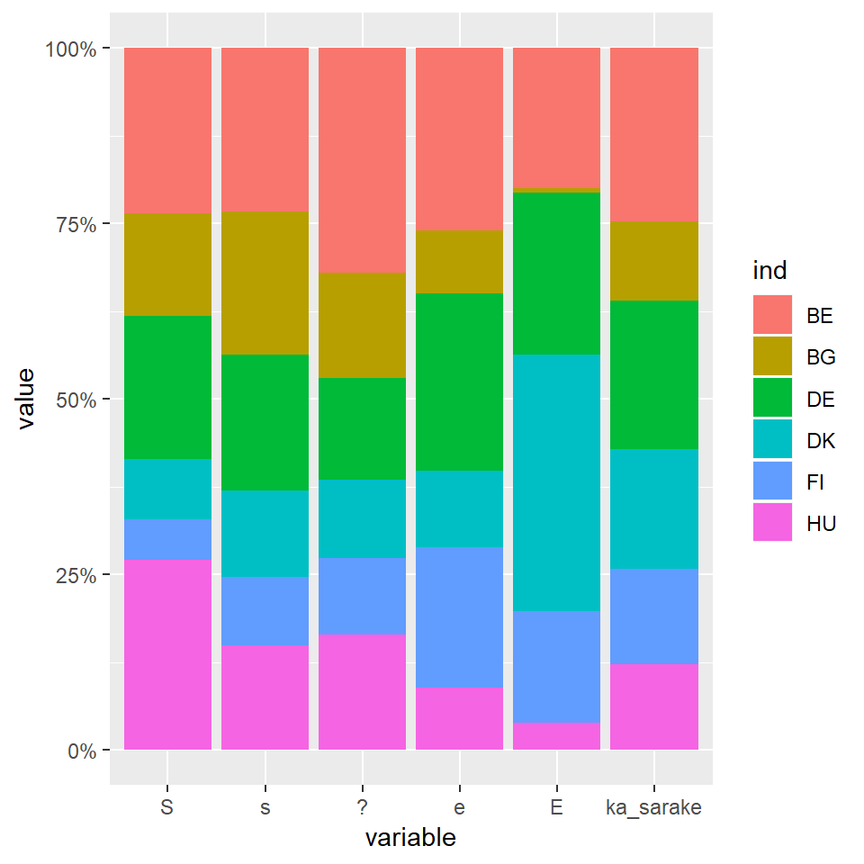

```r
#mutkikas kuvan piirto - sarakeprofiilit vertailussa
#ggplot vaatii df-rakenteen ja 'long data' - muotoon
##https://stackoverflow.com/questions/9563368/create-stacked-barplot-where-each-stack-is-scaled-to-sum-to
#
# käytetään ca - tuloksia
apu1 <- (simpleCA1$N)
colnames(apu1) <- c("S", "s", "?", "e", "E")
rownames(apu1) <- c("BE", "BG", "DE", "DK", "FI", "HU")
apu1_df <- as.data.frame(apu1)
#lasketan rivien reunajakauma
apu1_df$ka_sarake <- rowSums(apu1_df)
#muokataan 'long data' - muotoon
apu1b_df <- melt(cbind(apu1_df, ind = rownames(apu1_df)), id.vars = c('ind'))

ggplot(apu1b_df, aes(x = variable, y = value, fill = ind)) +
         geom_bar(position = "fill", stat ="identity") +
         scale_y_continuous(labels = percent_format())
```

```r
#apu1b_df
```

**zxy** Massat saa mukaan vaikka viittaamalla frekvenssitauluun (4.9.2018)

Riviprofiilikuva toimii, mutta vaatii vielä viilausta (18.9.2018)

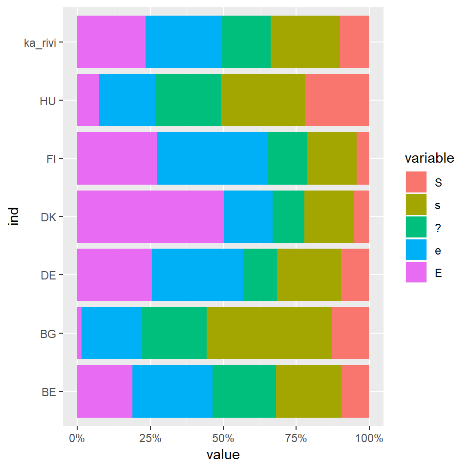

```r
# riviprofiilit ja keskiarvorivi -  18.9.2018
apu2_df <- as.data.frame(apu1)
apu2_df <- rbind(apu2_df, ka_rivi = colSums(apu2_df))

#apu2_df

#str(apu2_df)
## typeof(apu2_df) # what is it?
## class(apu2_df) # what is it? (sorry)
## storage.mode(apu2_df) # what is it? (very sorry)
## length(apu2_df) # how long is it? What about two dimensional
## objects?
# attributes(apu2_df)

# temp1 <- cbind(apu2_df, ind = rownames(apu2_df))
# temp1
##muokataan 'long data' - muotoon
apu2b_df <- melt(cbind(apu2_df, ind = rownames(apu2_df)), id.vars = c('ind'))
#apu2b_df
#
#
#ggplot(apu2b_df, aes(x = value, y = ind, fill = variable)) +
#       geom_bar(position = "fill", stat ="identity") +
#       #coord_flip() +
#        scale_x_continuous(labels = percent_format())
#versio2 # perkele, tämä toimii! 18.9.2018
ggplot(apu2b_df, aes(x = ind, y = value, fill = variable)) +
       geom_bar(position = "fill", stat ="identity") +
       coord_flip() +
        scale_y_continuous(labels = percent_format())
```

**Graafinen analyysi ja R**

Käytänön neuvoja data-analyysiin, kuulunee tekstiin, vai meneekö “ohjelmistoympäristö” -liitteeseen? Tärkeä juttu!

Kuvasuhteen saa oikeaksi, kun avaa g-ikkunan (X11()) ja sitten plot. Voi tallentaa pdf-muodossa grafiikkaikkunasta, ja ladata outputiin knitr-vaiheessa. Parempi tulostaa kuvatdsto pdf-ajurilla, jos lopulliseen versioon joutuu näin tekemään (13.5.2018 ). Tämä voi olla järkevä tapa analyysivaiheessa? Teksti kopsattu alla olevasta koodilohkosta.

Ensimmäinen korrespondenssianalyysi - kokeiluja kuvasuhteen säätämiseksi output-dokumentissa. RStudiossa voi avata komentokehoitteessa grafiikka-ikkunan. Siitä käsin tallennettu pdf-kuva on ladattu alla Rmarkdownin omalla komennolla, kohdistus keskelle. Parhaiten näyttäisi toimivan knitrin funktio, mutta oletuskuvakoolla saa ca-kuvasta näköjään aika lähelle oikeanlaisen ilman mitään temppuja.

**zxy** Selventäisikö vielä khii2-etäisyyksien taulukko, tai ehkä seuraavassa luvussa? **#V** MG&Blasius, “vihreän kirja”, johdanto.

Lähtökohta: suhteelliset frekvenssit (korrespondenssimatriisi P)

```r
taulu5 <-ISSP2012esim1.dat %>% tableX(maa,V6,type = "cell_perc")
knitr::kable(taulu5,digits = 2, booktabs = TRUE,
             caption = "Kysymyksen V6 vastaukset maittain (%)")
```

Kysymyksen V6 vastaukset maittain (%)

|  | S | s | ? | e | E | Total |
| --- | --- | --- | --- | --- | --- | --- |
| BE | 2.35 | 5.54 | 5.38 | 6.78 | 4.68 | 24.72 |
| BG | 1.45 | 4.85 | 2.52 | 2.33 | 0.16 | 11.31 |
| DE | 2.03 | 4.61 | 2.43 | 6.61 | 5.38 | 21.05 |
| DK | 0.86 | 2.92 | 1.87 | 2.85 | 8.55 | 17.05 |
| FI | 0.58 | 2.31 | 1.83 | 5.19 | 3.72 | 13.63 |
| HU | 2.69 | 3.54 | 2.76 | 2.33 | 0.92 | 12.24 |
| Total | 9.95 | 23.76 | 16.79 | 26.10 | 23.41 | 100.00 |

**zxy** Tätä ensimmäistä kuvaa on muistiinpanoissa kommentoitu (löytyy printattuna)

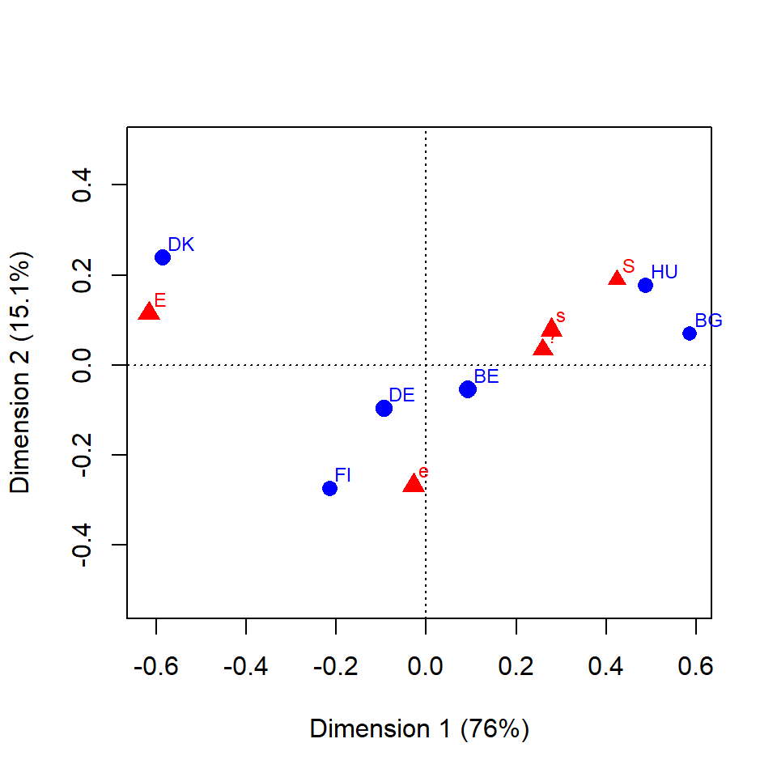

V6: lapsi kärsii jos äiti on töissä

```r
#simpleCA1 <- ca(~maa + V6,ISSP2012esim1.dat) suoritetaan ennen värikuvaa, tuloksia tarvitaan #siinä.
#symmetrinen kartta

plot(simpleCA1, map = "symmetric", mass = c(TRUE,TRUE))
```

```r
#str(simpleCA1)
# 13.5.2018
# kuvasuhteen saa oikeaksi, kun avaa g-ikkunan (X11()) ja sitten plot. Voi tallentaa pdf-muodossa
# grafiikkaikkunasta, ja ladata outputiin knitr-vaiheessa. Parempi tulostaa kuvatdsto pdf-ajurilla, jos lopulliseen versioon joutuu
# näin tekemään.
# näitä kokeiln chunk-optioissa mutta ei toimineet (out.width = "6", out.hight = "6") (13.5.2018), vaan pdf-konversiossa
# pandoc failed with error 43
#
```

Ja toinen tapa - kuvatiedoston lataaminen include_graphics - funktiolla. Ei esitetä tässä.

## 2.2 Korrespondenssianalyysin käsitteet

1. Profiilit
2. Massat
3. Profiilien etäisyydet (khii2)

**zxy** Ja tätä “triplettiä” täydentää neljä siitä johdettua käsitettä, viite muistiinpanoissa. **#V** Tässäkin CAiP - kirja hyvä apu, ja MG2017HY-luentokalvot.

# 3 Tulkinnan perusteita

Luvussa syvennetään esimerkin tulkinnan perusteita. Miksi symmetrinen kartta on yleensä paras vaihtoehto, siksi se oletusarvoisesti esitetäänkin. Milloin voi käyttää vaihtoehtoisia esitystapoja? **Ydinluku**.

Esimerkkiaineistossa tulee jo pohdittavaa, Guttman (arc, horseshoe) - efekti, ratkaisun dimensiot jne.

Asymmetrinen kartta, jossa riviprofiilit ovat pääkomponentti-koordinaateissa ja sarakeprofiilit standardikoordinaateissa.

1. Sarakkeet ideaalipisteinä, edustavat kuvittellisia maita joissa kaikki ovat vastanneet vain yhdellä tavalla.
2. Sarakepisteet kaukana origosta, koska skaalattu
3. Rivipisteet kasautuneet keskiarvopisteen ympärille
4. Rivi-ja sarakepisteiden suhteelliset sijannit samat kuin symmetrisessä kuvassa
5. Tässäkin kuvassa pisteen koko kuvaa sen massaa. Sarakkeista “täysin samaa mieltä” (ts) ja “ei samaa eikä eri mieltä” ovat massoiltaan pienimmät.
6. Pisteiden koko kuvaa rivin tai sarakkeen massaa.

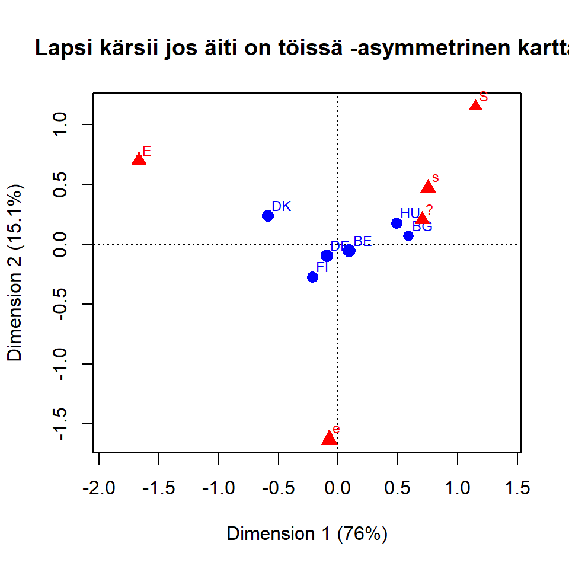

```r
#asymmetrinen kartta - rivit pc ja sarakkeet sc
plot(simpleCA1, map = "rowprincipal",
     mass = c(TRUE,TRUE),
     main = "Lapsi kärsii jos äiti on töissä -asymmetrinen kartta" )
```

Tarinaa voi tarvittaessa jatkaa, tämä on CA:n hankalin asia. Kaksi koordinaatistoa, ja niiden yhteys.

7. Asymmetrinen kuva ja akseleiden / dimensioiden tulkinta

Piirretään sama asymmetrinen kartta uudelleen, mutta yhdistetään sarakepisteet keskiarvopisteeseen (sentroidiin) suorilla. Mitä terävämpi on sarakesuoran (vektorin?) ja akselin kulma, sitä enemmän sarake määrittää tätä ulottuvuutta. Jos vektori on lähettä 45 asteen kulmaa, sarake määrittää yhtä paljon molempia ulottuvuuksia.

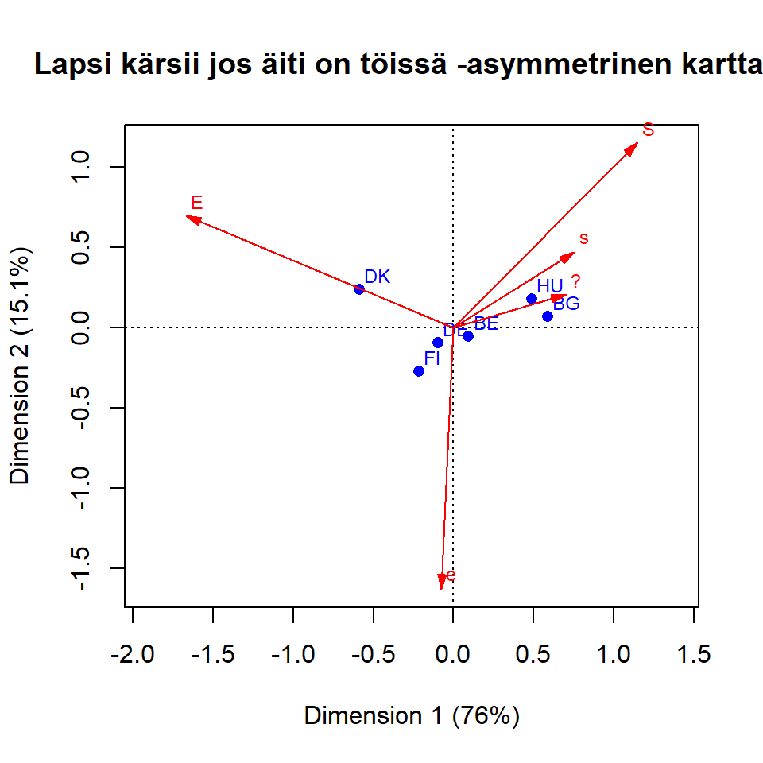

```r
# asymmetrinen kartta - rivit pc ja sarakkeet sc
# sarakkeet vektorikuvina
plot(simpleCA1, map = "rowprincipal",
     arrows = c(FALSE,TRUE),
     main = "Lapsi kärsii jos äiti on töissä -asymmetrinen kartta 1" )
```

Tärkein havainto on sarakkeen “Eri mieltä” (e) ja toisen ulottuvuuden yhteys. Myös sarake “täysin samaa mieltä” (ts) määrittää toista ulottuvuutta lähes yhtä paljon kuin ensimmäistä.

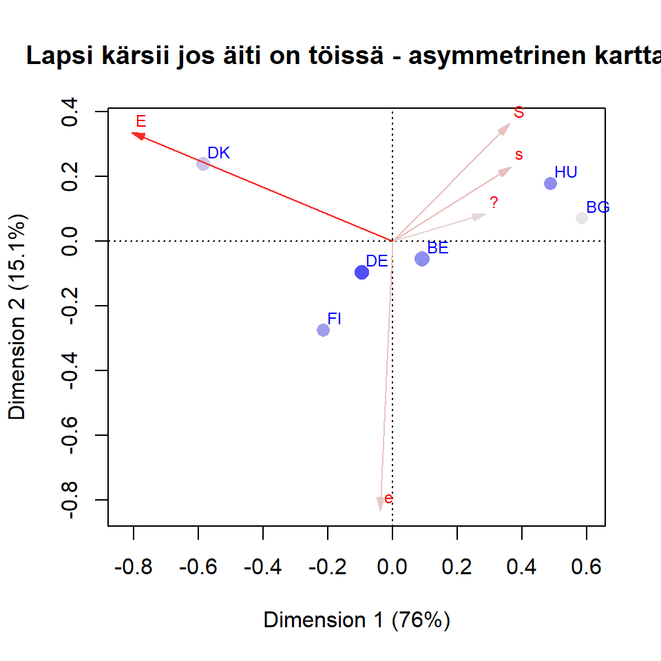

```r
#X11() komentoriville ja plot-komento
plot(simpleCA1, map = "rowgreen",
     contrib= c("absolute", "absolute"),
     mass = c(TRUE,TRUE),
     arrows = c(FALSE, TRUE),
     main = "Lapsi kärsii jos äiti on töissä - asymmetrinen kartta 2" )
```

Greenacre (2006, “loose ends -artikkeli”) ehdotti asymmetrisessä kuvassa standardikoordinaattien skaalaamista niin, että ne kerrotaan massan neliöjuurella. Tämä skaalaus toimii hyvin pienen ja suuren inertian tapauksessa. Kartoissa pätee sama sääntö kuin muussakin graafisessa data-analyyisissä, kuvien on esitettävä oleelliset yhteydet, mutta mielellään vain ne.

Asymmetrisessä kartassa 2 pisteiden koko on suhteessa niiden massaan, ja värisävy absoluuttiseen kontribuutioon (voi olla myös suhteellinen kontribuutio).

```r
# CA:n numeeriset tulokset
summary(simpleCA1)
```

```
##
## Principal inertias (eigenvalues):
##
##  dim    value      %   cum%   scree plot
##  1      0.136619  76.0  76.0  *******************
##  2      0.027089  15.1  91.1  ****
##  3      0.010054   5.6  96.7  *
##  4      0.005988   3.3 100.0  *
##         -------- -----
##  Total: 0.179751 100.0
##
##
## Rows:
##     name   mass  qlt  inr    k=1 cor ctr    k=2 cor ctr
## 1 |   BE |  247  465   34 |   93 347  16 |  -54 118  27 |
## 2 |   BG |  113  874  251 |  586 862 284 |   70  12  21 |
## 3 |   DE |  210  584   36 |  -94 291  14 |  -95 293  70 |
## 4 |   DK |  170  996  381 | -586 853 428 |  240 143 362 |
## 5 |   FI |  136 1000   92 | -214 380  46 | -274 620 377 |
## 6 |   HU |  122  889  206 |  487 783 213 |  179 105 144 |
##
## Columns:
##     name   mass  qlt  inr    k=1 cor ctr    k=2 cor ctr
## 1 |    S |   99  784  152 |  424 653 131 |  190 131 132 |
## 2 |    s |  238  788  140 |  278 731 134 |   78  57  53 |
## 3 |      |  168  720   88 |  259 707  82 |   34  12   7 |
## 4 |    e |  261  982  108 |  -28  11   2 | -268 971 693 |
## 5 |    E |  234 1000  512 | -616 966 651 |  115  34 114 |
```

**zxy** Taulukon käsitteiden läpikäynti ja pureskelu kuulunee seuraavaan lukuun.

# 4 Yksinkertaisen korrespondenssianalyysin laajennuksia 1

Korrespondenssianalyysi sallii rivien tai sarakkeiden yhdistelyn tai “jakamisen”. Tämä onnistuu esimerkkiaineistossa lisäämällä rivejä eli jakamalla eri maiden vastausksia useampaan ryhmään.

Sen avulla voi myös tarkastella ja vertailla erilaisia ryhmien välisiä tai ryhmien sisäisiä (within groups - between groups) eroja hieman. Teknisesti yksinkertaista korrespondenssianalyysiä sovelletaan muokattuun matriisiin. Datamatriisi rakennetaan useammasta alimatriisista, joko “pinoamalla” osamatriiseja (stacked matrices) tai muodostamalla symmetrinen lohkomatriisi (ABBA).

Lisätään esimerkkidataan uusia muuttujia, vastaajan luokitelut ikä ja sukupuoli.

** EDIT: ** Koitetaan aina pitää alkuperäinen data mahdollisimman “lähellä”, luodaan siis kaikki uudestaan. Tarketeena .data jos koko aineisto ja .dat jos rajattu. Aineisto laajennetaan myöhemmin?

Toinen pulma: milloin laajennetaan dataa useampaan maahan?

```r
# Saksan ja Belgian aluejako - täydentävät pisteet

ISSP2012esim1.data <- read_spss("data/ZA5900_v4-0-0.sav") # Alkuperäinen data, ( user_na = TRUE pois 25.9.2018)

#str(ISSP2012esim1.data)
#61754 obs. of  420 variables
#
# kuusi maata

incl_esim1 <- c(56, 100, 208, 246, 276, 348) #BE,BG,DK,FI,DE,HU)

ISSP2012esim1.dat <- filter(ISSP2012esim1.data, V4 %in% incl_esim1)

#str(ISSP2012esim1.dat) #8557 obs. of  420 variables
#
# mukaan muuttujat, V3 jos halutaan jakaa Saksa ja Belgia
# SEX 1=male, 2=female AGE haastateltava ikä haastatteluhetkellä
#

ISSP2012esim1.dat <- select(ISSP2012esim1.dat, C_ALPHAN, V3,V4, V6, SEX, AGE)

#str(ISSP2012esim1.dat) #8557 obs. of  6 variables
#
#poistetaan havainnot, joissa puuttuvia tietoja

ISSP2012esim1.dat <- filter(ISSP2012esim1.dat, (!is.na(V6) & !is.na(SEX) & !is.na(AGE)))

#str(ISSP2012esim1.dat) #8143 havaintoa, 6 muuttujaa
#8557-8143 = 414 havaintoa vähemmän

# sp (sukupuoli) m = 1, f = 2
sp_labels <- c("m","f")
#
# vastausvaihtoehdot
#
# 1 = täysin samaa mieltä, 2 = samaa mieltä, 3 = ei samaa eikä eri, 4 = eri mieltä, 5 = täysin eri mieltä
vastaus_labels <- c("S","s","?","e","E")

# Faktoreiksi - onko ihan oikein? On(26.9.18)

ISSP2012esim1.dat$maa <- factor(ISSP2012esim1.dat$C_ALPHAN)
ISSP2012esim1.dat$sp <- factor(ISSP2012esim1.dat$SEX, labels = sp_labels) #pitäisikö lisätä levels? Luodaan uusi muuttuja, ei tarvitse.
ISSP2012esim1.dat$V6 <- factor(ISSP2012esim1.dat$V6, labels = vastaus_labels) #pitäisikö lisätä levels? Ei uutta muuttujaa, toimii silti.
#str(ISSP2012esim1.dat)
#str(ISSP2012esim1.dat$sp)
#summary(ISSP2012esim1.dat)
#ISSP2012esim1.dat %>% tableX(sp, V6, type = "row_perc")
```

**EDIT:** Uudet muuttujat omassa koodilohkossa pätkänä

```r
# 23.5.2018 maa2 - muuttuja
# ISO 3166 Code kansallisvaltiolle muuttujassa V4
#
# ISO 3166 Code V3 - maiden jaot
#  5601     BE-FLA-Belgium/ Flanders
#  5602     BE-WAL-Belgium/ Wallonia
#  5603     BE-BRU-Belgium/ Brussels
# 27601     DE-W-Germany-West
# 27602     DE-E-Germany-East
ISSP2012esim1.dat$maa2 <- factor(ISSP2012esim1.dat$V3,
                  levels = c("100","208","246","348","5601","5602","5603","27601","27602"),
                  labels = c("BG","DK","FI","HU","bF","bW","bB","dW","dE"))

#head(ISSP2012esim1.dat)
#str(ISSP2012esim1.dat$maa2)
#taulu41 <- ISSP2012esim1.dat %>% tableX(maa,maa2,type = "count") # Tarkistus maa2-muuttujalle
#kable(taulu41,digits = 2, caption = "Uusi muuttuja maa2: Belgian ja Saksan ositus")
```

**zxy** Edellä pelkkä tarkistus, tuloksen voi kopsata koodilohkoon kun homma on hoidettu.

## 4.1 Täydentävät muuttujat (supplementary points)

**zxy** Piste sinne piirretään, mutta muuttujassa on se tieto. “Täydentävät piste”" kuulostaa huonolta. Lisämuuttujat, havainnot?

Ref:CAip ss 89, HY2017_MCA

Aineistossa on havaintoja (rivejä) tai muuttujia (sarakkeita), joista voi olla hyötyä tulosten tulkinnassa. Nämä lisäpisteet voidaan sijoittaa kartalle, jos niitä voidaan jotenkin järkevästi vertailla kartan luomisessa käytettyihin profiileihin (riveihin ja sarakkeisiin).

**EDIT** Lisätään Belgian ja Saksan aluejako täydentäviksi riveiksi. Sopii tarinaan, dimensioiden tulkinta ei ollut esimerkissä kovin kirkas. Viite CAip:n lukuun, jossa vain todetaan että maita ei ole järkevää painottaa (massa) otoskoolla, vaan vakioidaan (jotenkin) sama (suhteellinen) massa kaikille. Samalla oikaistaan myös naisten yliedustus aineistossa.

Active point, aktiivinen piste (aktiivinen havainto tai muuttuja).

Täydentävä piste (täydentävä havainto).

Täydentävien muuttujien kolme käyttötapaa:

- sisällöllisesti tutkimusongelman kannalta poikkeava tai erilainen rivi tai sarake
- outlayerit, poikkeava havainto jolla pieni massa (esimerkissä uusi sarakemuuttuja, jossa kovin vähän havaintoja)
- osaryhmät **EDIT** capaper- jäsentelyssä ja bookdown-dokumentissa selitetetty täydentävät/lisäpisteet tarkemmin (18.9.2018).

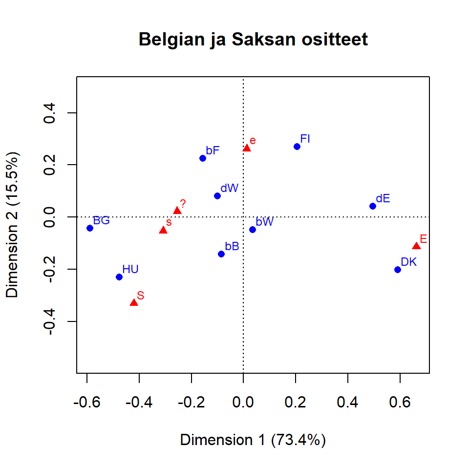

```r
#kömpelöä koodia, harjoitellaan taulukoiden yhdistelyä (CAtest1.Rmd)
# Belgian ja Sakasan jako lisäpisteinä 24.5.2018
#head(ISSP2012esim1.dat)

# HUOM! Tässä ei vielä supp.points mukana!
suppointCA1 <- ca(~maa2 + V6,ISSP2012esim1.dat)
plot(suppointCA1, main = "Belgian ja Saksan ositteet")
```

```r
#kuva kääntyy ympäri, kerrotaan koordinaattivektorit luvulla -1
#summary(suppointCA1)
#print(suppointCA1)
#str(suppointCA1)
#
#Käännetään kuva

suppointCA1b <- suppointCA1
suppointCA1b$rowcoord <- suppointCA1b$rowcoord[,] * (-1)
suppointCA1b$colcoord <- suppointCA1b$colcoord[,] * (-1)
suppointCA1b$rowcoord
```

|  | Dim1 | Dim2 | Dim3 | Dim4 |
| --- | --- | --- | --- | --- |
| BG | 1.5024575 | 0.2364976 | -1.5646535 | 1.2274009 |
| DK | -1.5060223 | 1.1214678 | -0.8891868 | 0.1996764 |
| FI | -0.5252216 | -1.5009862 | 0.5841156 | 0.1935193 |
| HU | 1.2154623 | 1.2803425 | 0.9947716 | -0.9386679 |
| bF | 0.4000647 | -1.2540425 | -1.1182121 | -1.6025782 |
| bW | -0.0906315 | 0.2679979 | 0.0761877 | -0.7901000 |
| bB | 0.2169124 | 0.7893585 | 1.3697862 | -0.5617393 |
| dW | 0.2543232 | -0.4511235 | 0.8757353 | 1.5124903 |
| dE | -1.2620072 | -0.2265947 | 0.7448562 | -0.2844804 |

```r
suppointCA1b$colcoord
```

|  | Dim1 | Dim2 | Dim3 | Dim4 |
| --- | --- | --- | --- | --- |
| S | 1.0733103 | 1.8351327 | 2.1160478 | -0.2360525 |
| s | 0.7872571 | 0.2909285 | -0.9861563 | 1.2374779 |
| ? | 0.6497888 | -0.1199336 | -0.9123790 | -1.9203632 |
| e | -0.0298593 | -1.4515479 | 0.8247769 | 0.2094281 |
| E | -1.6881081 | 0.6291103 | -0.1632819 | -0.0121801 |

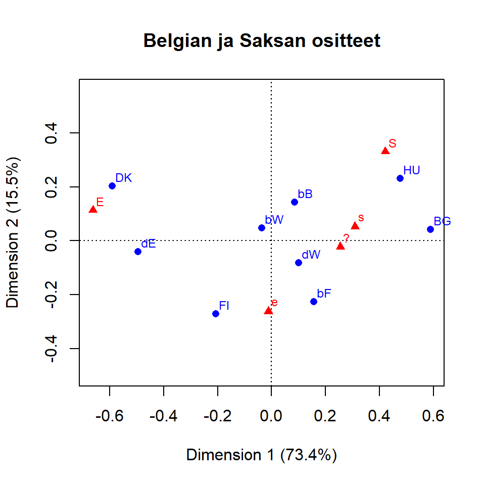

```r
plot(suppointCA1b, main = "Belgian ja Saksan ositteet")
```

```r
# Miten lisärivit? (24.5.2018)
# Luetaan data tauluksi - ei toimi, char-table
# yritetään uudestaan table-funktiolla
# data maa2-muuttujalla
suppoint1_df1 <- select(ISSP2012esim1.dat, maa2,V6)
#str(suppoint1_df1)
#head(suppoint1_df1)
suppoint1_tab1 <- table(suppoint1_df1$maa2, suppoint1_df1$V6)
suppoint1_tab1
```

| / | S | s | ? | e | E |
| --- | --- | --- | --- | --- | --- |
| BG | 118 | 395 | 205 | 190 | 13 |
| DK | 70 | 238 | 152 | 232 | 696 |
| FI | 47 | 188 | 149 | 423 | 303 |
| HU | 219 | 288 | 225 | 190 | 75 |
| bF | 51 | 241 | 262 | 312 | 146 |
| bW | 53 | 103 | 91 | 118 | 125 |
| bB | 87 | 107 | 85 | 122 | 110 |
| dW | 133 | 313 | 138 | 375 | 208 |
| dE | 32 | 62 | 60 | 163 | 230 |

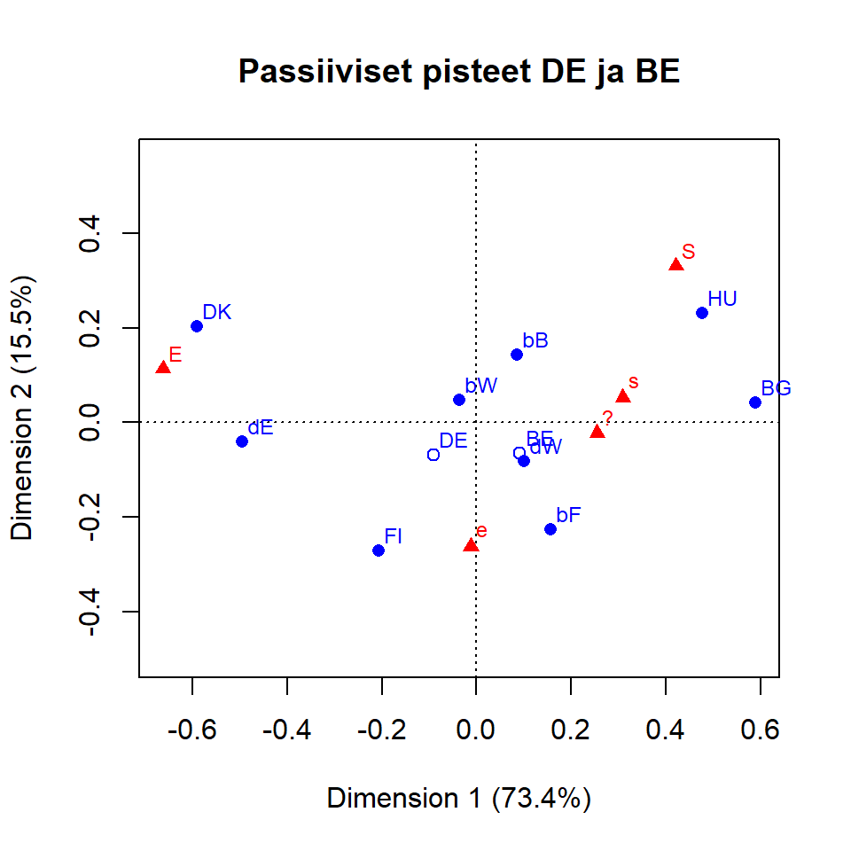

```r
#plot(ca(~maa2 + V6, suppoint1_df1)) #toimii
#
# Saksan ja Belgian summarivit
#
suppoint2_df <- filter(ISSP2012esim1.dat, (maa == "BE" | maa == "DE"))
suppoint2_df <- select(suppoint2_df, maa, V6)
#head(suppoint2_df)
#tail(suppoint2_df)
#str(suppoint2_df)
#suppoint2_df
suppoint2_tab1 <- table(suppoint2_df$maa, suppoint2_df$V6)
#suppoint2_tab1
suppoint2_tab1 <- suppoint2_tab1[-2,]
# kömpelösti kolme kertaa
suppoint2_tab1 <- suppoint2_tab1[-3,]
suppoint2_tab1 <- suppoint2_tab1[-3,]
suppoint2_tab1 <- suppoint2_tab1[-3,]
#suppoint2_tab1

#lisätään rivit maa2-muuttujan taulukkoon

suppoint1_tab1 <- rbind(suppoint1_tab1, suppoint2_tab1)
#suppoint1_tab1
suppointCA2 <- ca(suppoint1_tab1[,1:5], suprow = 10:11)
#käännetään kuva
suppointCA2b <- suppointCA2
suppointCA2b$rowcoord <- suppointCA2b$rowcoord[,] * (-1)
suppointCA2b$colcoord <- suppointCA2b$colcoord[,] * (-1)

plot(suppointCA2b, main = "Passiiviset pisteet DE ja BE" )
```

```r
# ca- output
#names(suppointCA2b)
#str(suppointCA2b)
#str(suppointCA2b$rowcoord)
#uppointCA2b
#suppointCA2b$rowcoord
#apply(suppointCA2b$rowcoord, 2, sum)
#suppointCA2b$rowdist
#suppointCA2b$coldist
summary(suppointCA2b)
```

```
##
## Principal inertias (eigenvalues):
##
##  dim    value      %   cum%   scree plot
##  1      0.154101  73.4  73.4  ******************
##  2      0.032489  15.5  88.9  ****
##  3      0.014294   6.8  95.7  **
##  4      0.008944   4.3 100.0  *
##         -------- -----
##  Total: 0.209828 100.0
##
##
## Rows:
##       name   mass  qlt  inr    k=1 cor  ctr    k=2 cor  ctr
## 1  |    BG |  113  878  215 |  590 874  255 |   43   5    6 |
## 2  |    DK |  170  971  327 | -591 869  387 |  202 102  214 |
## 3  |    FI |  136  957   79 | -206 352   38 | -271 605  307 |
## 4  |    HU |  122  927  177 |  477 751  181 |  231 176  201 |
## 5  |    bF |  124  650   69 |  157 212   20 | -226 438  195 |
## 6  |    bW |   60  388    3 |  -36 137    0 |   48 252    4 |
## 7  |    bB |   63  481   17 |   85 127    3 |  142 354   39 |
## 8  |    dW |  143  345   33 |  100 208    9 |  -81 138   29 |
## 9  |    dE |   67  966   82 | -495 960  107 |  -41   7    3 |
## 10 | (*)BE | <NA>  512 <NA> |   92 338 <NA> |  -66 173 <NA> |
## 11 | (*)DE | <NA>  418 <NA> |  -90 265 <NA> |  -68 153 <NA> |
##
## Columns:
##     name   mass  qlt  inr    k=1 cor ctr    k=2 cor ctr
## 1 |    S |   99  816  167 |  421 505 115 |  331 311 335 |
## 2 |    s |  238  781  143 |  309 759 147 |   52  22  20 |
## 3 |      |  168  594   88 |  255 589  71 |  -22   4   2 |
## 4 |    e |  261  871   98 |  -12   2   0 | -262 870 550 |
## 5 |    E |  234  999  505 | -663 971 667 |  113  28  93 |
```

Saksan ja Belgian summarivit ovat ositteiden painotettuja keskiarvoja (sentroideja), läntisen ja itäisen Saksan rivipisteiden välisellä janalla on koko maan summapiste DE.

Piirretään vertailun vuoksi vielä asymmettrinen kartta (“kontribuutio-kartta, kontribuutio-kaksoiskuva”).

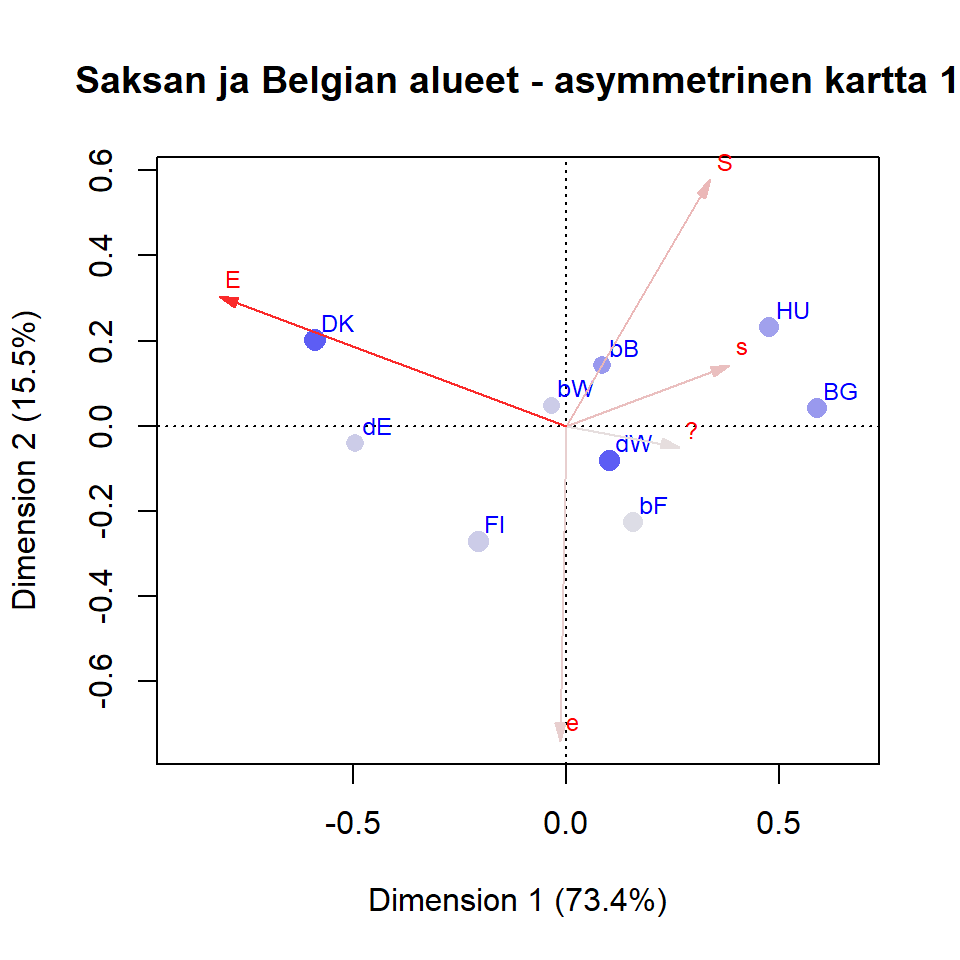

```r
#X11()
plot(suppointCA1b, map = "rowgreen",
     contrib= c("absolute", "absolute"),
     mass = c(TRUE,TRUE),
     arrows = c(FALSE, TRUE),
     main = "Saksan ja Belgian alueet - asymmetrinen kartta 1" )
```

Tulostetaan numeeriset taulukot.

```r
summary(suppointCA1b)
```

```
##
## Principal inertias (eigenvalues):
##
##  dim    value      %   cum%   scree plot
##  1      0.154101  73.4  73.4  ******************
##  2      0.032489  15.5  88.9  ****
##  3      0.014294   6.8  95.7  **
##  4      0.008944   4.3 100.0  *
##         -------- -----
##  Total: 0.209828 100.0
##
##
## Rows:
##     name   mass  qlt  inr    k=1 cor ctr    k=2 cor ctr
## 1 |   BG |  113  878  215 |  590 874 255 |   43   5   6 |
## 2 |   DK |  170  971  327 | -591 869 387 |  202 102 214 |
## 3 |   FI |  136  957   79 | -206 352  38 | -271 605 307 |
## 4 |   HU |  122  927  177 |  477 751 181 |  231 176 201 |
## 5 |   bF |  124  650   69 |  157 212  20 | -226 438 195 |
## 6 |   bW |   60  388    3 |  -36 137   0 |   48 252   4 |
## 7 |   bB |   63  481   17 |   85 127   3 |  142 354  39 |
## 8 |   dW |  143  345   33 |  100 208   9 |  -81 138  29 |
## 9 |   dE |   67  966   82 | -495 960 107 |  -41   7   3 |
##
## Columns:
##     name   mass  qlt  inr    k=1 cor ctr    k=2 cor ctr
## 1 |    S |   99  816  167 |  421 505 115 |  331 311 335 |
## 2 |    s |  238  781  143 |  309 759 147 |   52  22  20 |
## 3 |      |  168  594   88 |  255 589  71 |  -22   4   2 |
## 4 |    e |  261  871   98 |  -12   2   0 | -262 870 550 |
## 5 |    E |  234  999  505 | -663 971 667 |  113  28  93 |
```

## 4.2 Lisämuuttujat: ikäluokka ja sukupuoli

**zxy** Otsikkoa pitää harkita, CAip - kirjassa tämä on ensimmäinen esimerkki yksinkertaisen CA:n laajennuksesta. Otsikkona on “multiway tables”, ja tästä yhteisvaikutusmuuttujan (interactive coding) luominen on ensimmäinen esimerkki. Menetelmää taivutetaan sen jälkeen moneen suuntaan.

Luodaan luokiteltu ikämuuttua age_cat, ja sen avulla iän ja sukupuolen interaktiomuuttuja ga. Maiden välillä on hieman eroja siinä, kuinka nuoria vastaajia on otettu tutkimuksen kohteeksi. Suomessa alaikäraja on 15 vuotta, monessa maassa se on hieman korkeampi. Ikäluokat ovat (1=15-25, 2 =26-35, 3=36-45, 4=46-55, 5=56-65, 6= 66 tai vanhempi). Vuorovaikutusmuuttuja ga koodataan f1,…, f6 ja m1,…,m6. Muuttujien nimet kannattaa pitää mahdollisimman lyhyinä.

```r
# Iän ja sukupuolen vuorovaikutusmuuttujia 1
#
# Uusi R-data: ISSP2012esim2.dat
#
#age_cat
#AGE 1=15-25, 2 =26-35, 3=36-45, 4=46-55, 5=56-65, 6= 66 and older
#
#summary(ISSP2012esim1.dat$AGE)
#hist(ISSP2012esim1.dat$AGE)
ISSP2012esim2.dat <- mutate(ISSP2012esim1.dat, age_cat = ifelse(AGE %in% 15:25, "1",
                        ifelse(AGE %in% 26:35, "2",
                        ifelse(AGE %in% 36:45, "3",
                        ifelse(AGE %in% 46:55, "4",
                        ifelse(AGE %in% 56:65, "5", "6"))))))
ISSP2012esim2.dat$age_cat <- factor(ISSP2012esim2.dat$age_cat)

#test6 %>% tableX(AGE, age_cat, type = "count") aika iso taulukko, voi tarkistaa että muunnos ok.
taulu42 <- ISSP2012esim2.dat %>% tableX(maa,age_cat,type = "count")
kable(taulu42,digits = 2, caption = "Ikäluokka age_cat")
```

Ikäluokka age_cat

|  | 1 | 2 | 3 | 4 | 5 | 6 | Total |
| --- | --- | --- | --- | --- | --- | --- | --- |
| BE | 208 | 333 | 336 | 375 | 368 | 393 | 2013 |
| BG | 77 | 115 | 159 | 148 | 198 | 224 | 921 |
| DE | 205 | 223 | 274 | 358 | 288 | 366 | 1714 |
| DK | 207 | 213 | 245 | 271 | 234 | 218 | 1388 |
| FI | 152 | 166 | 165 | 223 | 238 | 166 | 1110 |
| HU | 103 | 161 | 198 | 171 | 196 | 168 | 997 |
| Total | 952 | 1211 | 1377 | 1546 | 1522 | 1535 | 8143 |

```r
taulu43 <- ISSP2012esim2.dat %>% tableX(maa,age_cat,type = "cell_perc")
kable(taulu43,digits = 2, caption = "age_cat: suhteelliset frekvenssit")
```

age_cat: suhteelliset frekvenssit

|  | 1 | 2 | 3 | 4 | 5 | 6 | Total |
| --- | --- | --- | --- | --- | --- | --- | --- |
| BE | 2.55 | 4.09 | 4.13 | 4.61 | 4.52 | 4.83 | 24.72 |
| BG | 0.95 | 1.41 | 1.95 | 1.82 | 2.43 | 2.75 | 11.31 |
| DE | 2.52 | 2.74 | 3.36 | 4.40 | 3.54 | 4.49 | 21.05 |
| DK | 2.54 | 2.62 | 3.01 | 3.33 | 2.87 | 2.68 | 17.05 |
| FI | 1.87 | 2.04 | 2.03 | 2.74 | 2.92 | 2.04 | 13.63 |
| HU | 1.26 | 1.98 | 2.43 | 2.10 | 2.41 | 2.06 | 12.24 |
| Total | 11.69 | 14.87 | 16.91 | 18.99 | 18.69 | 18.85 | 100.00 |

Ikäjäkauma painottuu kaikissa maissa jonkinverran vanhempiin ikäluokkiin. Nuorempien ikäluokkien osuus on (alle 26-vuotiaan ja alle 26-35 - vuotiaat) varsinkin Bulgariassa (BG) ja Unkarissa (HU) pieni.

**zxy** Siistimmät versioit muuttujien luonnista (case_when - rakenne) (19.9.2018).

```r
# case_when: ikä ja sukupuoli
ISSP2012esim2.dat <- mutate(ISSP2012esim2.dat, ga = case_when((age_cat == "1")&(sp == "m") ~ "m1",
                                       (age_cat == "2")&(sp == "m") ~ "m2",
                                       (age_cat == "3")&(sp == "m") ~ "m3",
                                       (age_cat == "4")&(sp == "m") ~ "m4",
                                       (age_cat == "5")&(sp == "m") ~ "m5",
                                       (age_cat == "6")&(sp == "m") ~ "m6",
                                       (age_cat == "1")&(sp == "f") ~ "f1",
                                       (age_cat == "2")&(sp == "f") ~ "f2",
                                       (age_cat == "3")&(sp == "f") ~ "f3",
                                       (age_cat == "4")&(sp == "f") ~ "f4",
                                       (age_cat == "4")&(sp == "f") ~ "f4",
                                       (age_cat == "5")&(sp == "f") ~ "f5",
                                       (age_cat == "6")&(sp == "f") ~ "f6",
                                       TRUE ~ "missing"
                                  ))
#ISSP2012esim1.dat %>% tableX(ga,ga2) # tarkistus uudelle muuttujan luontikoodille
# muuttujien tarkistuksia 19.9.2018
#str(ISSP2012esim1.dat$ga)
#str(ISSP2012esim1.dat$ga2)
# ga on merkkijono, samoin ga2, pitäisikö muuttaa faktoriksi?
#str(ISSP2012esim1.dat)

#Tulostetaan taulukkoina ga2 - muuttuja.
taulu46 <- ISSP2012esim2.dat %>% tableX(maa,ga,type = "count")
kable(taulu46,digits = 2, caption = "Ikäluokka ja sukupuoli ga2")
```

Ikäluokka ja sukupuoli ga2

|  | f1 | f2 | f3 | f4 | f5 | f6 | m1 | m2 | m3 | m4 | m5 | m6 | Total |
| --- | --- | --- | --- | --- | --- | --- | --- | --- | --- | --- | --- | --- | --- |
| BE | 116 | 198 | 174 | 199 | 186 | 185 | 92 | 135 | 162 | 176 | 182 | 208 | 2013 |
| BG | 40 | 64 | 94 | 85 | 114 | 149 | 37 | 51 | 65 | 63 | 84 | 75 | 921 |
| DE | 102 | 120 | 152 | 186 | 135 | 185 | 103 | 103 | 122 | 172 | 153 | 181 | 1714 |
| DK | 83 | 110 | 136 | 146 | 128 | 99 | 124 | 103 | 109 | 125 | 106 | 119 | 1388 |
| FI | 94 | 95 | 94 | 118 | 142 | 91 | 58 | 71 | 71 | 105 | 96 | 75 | 1110 |
| HU | 54 | 86 | 95 | 91 | 94 | 104 | 49 | 75 | 103 | 80 | 102 | 64 | 997 |
| Total | 489 | 673 | 745 | 825 | 799 | 813 | 463 | 538 | 632 | 721 | 723 | 722 | 8143 |

```r
taulu47 <- ISSP2012esim2.dat %>% tableX(maa,ga,type = "cell_perc")
kable(taulu47,digits = 2, caption = "ga2: suhteelliset frekvenssit")
```

ga2: suhteelliset frekvenssit

|  | f1 | f2 | f3 | f4 | f5 | f6 | m1 | m2 | m3 | m4 | m5 | m6 | Total |
| --- | --- | --- | --- | --- | --- | --- | --- | --- | --- | --- | --- | --- | --- |
| BE | 1.42 | 2.43 | 2.14 | 2.44 | 2.28 | 2.27 | 1.13 | 1.66 | 1.99 | 2.16 | 2.24 | 2.55 | 24.72 |
| BG | 0.49 | 0.79 | 1.15 | 1.04 | 1.40 | 1.83 | 0.45 | 0.63 | 0.80 | 0.77 | 1.03 | 0.92 | 11.31 |
| DE | 1.25 | 1.47 | 1.87 | 2.28 | 1.66 | 2.27 | 1.26 | 1.26 | 1.50 | 2.11 | 1.88 | 2.22 | 21.05 |
| DK | 1.02 | 1.35 | 1.67 | 1.79 | 1.57 | 1.22 | 1.52 | 1.26 | 1.34 | 1.54 | 1.30 | 1.46 | 17.05 |
| FI | 1.15 | 1.17 | 1.15 | 1.45 | 1.74 | 1.12 | 0.71 | 0.87 | 0.87 | 1.29 | 1.18 | 0.92 | 13.63 |
| HU | 0.66 | 1.06 | 1.17 | 1.12 | 1.15 | 1.28 | 0.60 | 0.92 | 1.26 | 0.98 | 1.25 | 0.79 | 12.24 |
| Total | 6.01 | 8.26 | 9.15 | 10.13 | 9.81 | 9.98 | 5.69 | 6.61 | 7.76 | 8.85 | 8.88 | 8.87 | 100.00 |

**edit** Vain tarkistuksiin, toisen voi poistaa (19.9.2018)!

CAiP, ch16, täällä myös maa- ja sukupuoli- uudelleenpainotus.

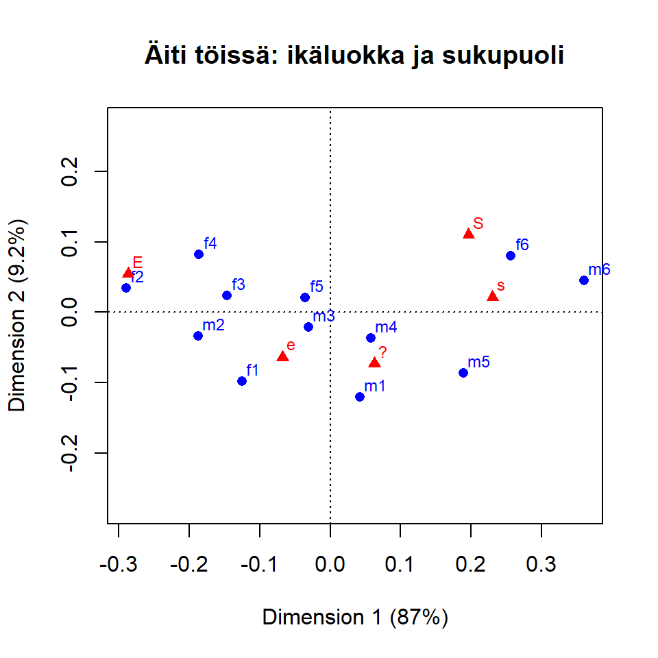

```r
gaTestCA1 <- ca(~ga + V6,ISSP2012esim2.dat)
plot(gaTestCA1, main = "Äiti töissä: ikäluokka ja sukupuoli")
```

```r
summary(gaTestCA1)
```

```
##
## Principal inertias (eigenvalues):
##
##  dim    value      %   cum%   scree plot
##  1      0.037448  87.0  87.0  **********************
##  2      0.003977   9.2  96.2  **
##  3      0.001041   2.4  98.6  *
##  4      0.000590   1.4 100.0
##         -------- -----
##  Total: 0.043055 100.0
##
##
## Rows:
##      name   mass  qlt  inr    k=1 cor ctr    k=2 cor ctr
## 1  |   f1 |   60  990   36 | -125 614  25 |  -98 376 145 |
## 2  |   f2 |   83  997  163 | -289 983 185 |   35  14  25 |
## 3  |   f3 |   91  984   47 | -146 958  52 |   24  26  13 |
## 4  |   f4 |  101 1000   97 | -186 836  93 |   82 164 172 |
## 5  |   f5 |   98  879    4 |  -35 658   3 |   20 221  10 |
## 6  |   f6 |  100  951  176 |  256 866 175 |   80  85 162 |
## 7  |   m1 |   57  659   32 |   42  72   3 | -120 587 205 |
## 8  |   m2 |   66  977   57 | -187 946  62 |  -34  30  19 |
## 9  |   m3 |   78  457    5 |  -31 318   2 |  -20 139   8 |
## 10 |   m4 |   89  674   14 |   58 482   8 |  -37 192  30 |
## 11 |   m5 |   89  988   90 |  189 818  85 |  -86 170 166 |
## 12 |   m6 |   89  978  277 |  360 963 307 |   45  15  45 |
##
## Columns:
##     name   mass  qlt  inr    k=1 cor ctr    k=2 cor ctr
## 1 |    S |   99  915  128 |  196 695 102 |  110 220 304 |
## 2 |    s |  238  969  304 |  230 961 336 |   21   8  27 |
## 3 |      |  168  777   46 |   62 330  17 |  -73 447 223 |
## 4 |    e |  261  897   58 |  -68 473  32 |  -64 424 268 |
## 5 |    E |  234  997  464 | -286 962 513 |   55  35 177 |
```

**zxy** Ei kovin kiinnostava, mutta voi verrata sekä edellisiin maa-vertailuihin että maan, ikäluokan ja sukupuolen yhteisvaikutusmuuttujan tuloksiin. MG tutkailee eri kysymyksellä tätä samaa asiaa, ja havaitsee että (a) maiden erot suuria ja sukupuolten pieniä (b) naiset liberaalimpia kuin miehet.

**zxy** miten pitäisi tulkita “oikealle kaatunut U - muoto” miehillä ja naisilla? Järjestys ei toimi, jotain muuta pelissä?

**zxy** On kiinnostava, mutta aika yksiuloitteinen (87 prosenttia ensimmäisellä dimensiolla). **pisteet voisi yhdistää? (29.9.18)**

```r
# Luodaan aineistoon kolmen muuttujan yhdysvaikutusmuuttuja maaga, maa, ikäluokka ja sukupuoli.
# Yleensä ei yhdysvaikuksissa mennä yli kolmen luokittelumuuttujan, ja tässäkin vain maiden pieni lukumää
# tekee tarkastelun aika helpoksi.

ISSP2012esim2.dat <- mutate(ISSP2012esim2.dat, maaga = paste(maa, ga, sep = ""))

ISSP2012esim2.dat %>% tableX(maa, maaga) # tarkistus, muunnos ok
```

| maa/maaga | BEf1 | BEf2 | BEf3 | BEf4 | BEf5 | BEf6 | BEm1 | BEm2 | BEm3 | BEm4 | BEm5 | BEm6 | BGf1 | BGf2 | BGf3 | BGf4 | BGf5 | BGf6 | BGm1 | BGm2 | BGm3 | BGm4 | BGm5 | BGm6 | DEf1 | DEf2 | DEf3 | DEf4 | DEf5 | … |
| --- | --- | --- | --- | --- | --- | --- | --- | --- | --- | --- | --- | --- | --- | --- | --- | --- | --- | --- | --- | --- | --- | --- | --- | --- | --- | --- | --- | --- | --- | --- |
| BE | 116 | 198 | 174 | 199 | 186 | 185 | 92 | 135 | 162 | 176 | 182 | 208 | 0 | 0 | 0 | 0 | 0 | 0 | 0 | 0 | 0 | 0 | 0 | 0 | 0 | 0 | 0 | 0 | 0 | … |
| BG | 0 | 0 | 0 | 0 | 0 | 0 | 0 | 0 | 0 | 0 | 0 | 0 | 40 | 64 | 94 | 85 | 114 | 149 | 37 | 51 | 65 | 63 | 84 | 75 | 0 | 0 | 0 | 0 | 0 | … |
| DE | 0 | 0 | 0 | 0 | 0 | 0 | 0 | 0 | 0 | 0 | 0 | 0 | 0 | 0 | 0 | 0 | 0 | 0 | 0 | 0 | 0 | 0 | 0 | 0 | 102 | 120 | 152 | 186 | 135 | … |
| DK | 0 | 0 | 0 | 0 | 0 | 0 | 0 | 0 | 0 | 0 | 0 | 0 | 0 | 0 | 0 | 0 | 0 | 0 | 0 | 0 | 0 | 0 | 0 | 0 | 0 | 0 | 0 | 0 | 0 | … |
| FI | 0 | 0 | 0 | 0 | 0 | 0 | 0 | 0 | 0 | 0 | 0 | 0 | 0 | 0 | 0 | 0 | 0 | 0 | 0 | 0 | 0 | 0 | 0 | 0 | 0 | 0 | 0 | 0 | 0 | … |
| HU | 0 | 0 | 0 | 0 | 0 | 0 | 0 | 0 | 0 | 0 | 0 | 0 | 0 | 0 | 0 | 0 | 0 | 0 | 0 | 0 | 0 | 0 | 0 | 0 | 0 | 0 | 0 | 0 | 0 | … |
| Total | 116 | 198 | 174 | 199 | 186 | 185 | 92 | 135 | 162 | 176 | 182 | 208 | 40 | 64 | 94 | 85 | 114 | 149 | 37 | 51 | 65 | 63 | 84 | 75 | 102 | 120 | 152 | 186 | 135 | … |

```r
#head(ISSP2012esim2.dat)
#str(ISSP2012esim2.dat)
```

**TARKISTA - ja maat voisi lisätä täydentävinä pisteinä (26.9.2018)**

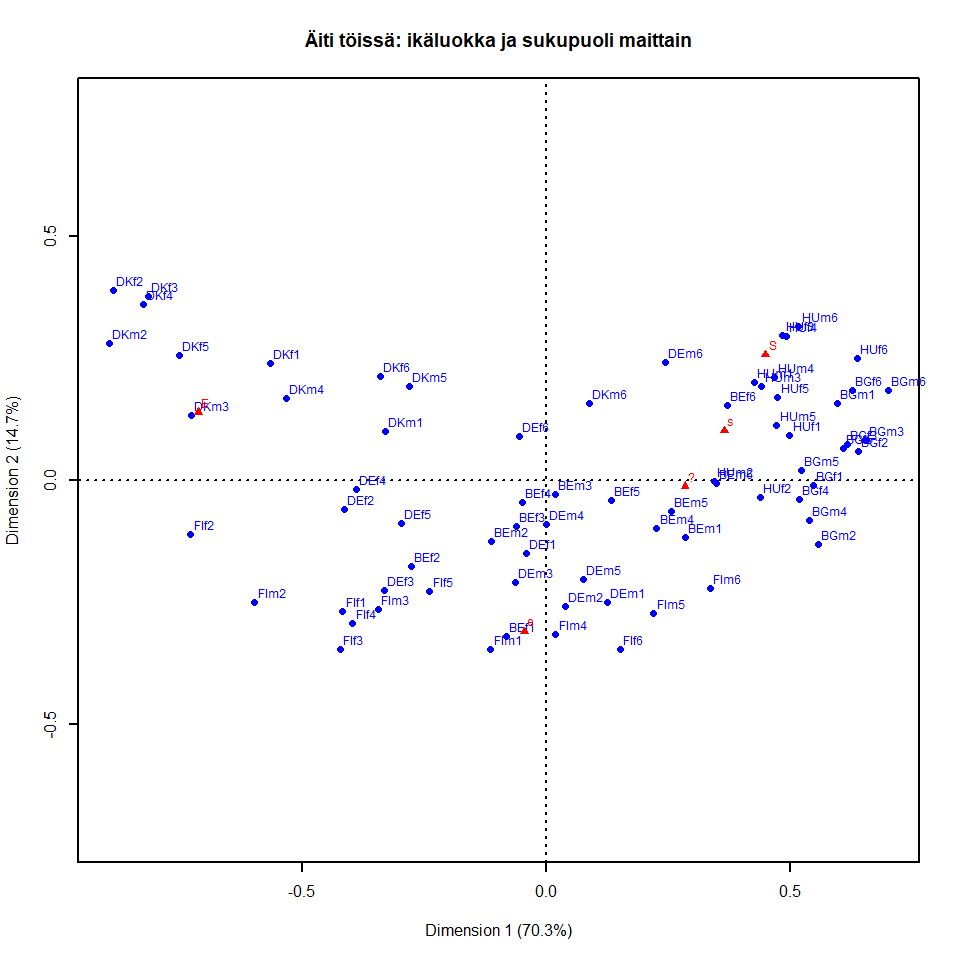

```r
maagaTestCA1 <- ca(~maaga + V6,ISSP2012esim2.dat)
# par("cex"= 0.5, "offset" = 0.5) ei toimi
par("cex"= 0.5)
plot(maagaTestCA1, main = "Äiti töissä: ikäluokka ja sukupuoli maittain", "offset" = 0.5)
```

```r
#str(maagaTestCA1)
# lisätään maapisteet frekvenssitaulukkoon maagaTestCA1$N (26.9.18)? Aika hankalaa...
# maagaTestCA1$N
#maagaTestCA1$rownames
ISSP2012esim2.dat %>% tableX(maaga, V6) # aika pieniä frekvenssejä soluissa!
```

| maaga/V6 | S | s | ? | e | E | Total |
| --- | --- | --- | --- | --- | --- | --- |
| BEf1 | 5 | 15 | 28 | 43 | 25 | 116 |
| BEf2 | 10 | 26 | 34 | 66 | 62 | 198 |
| BEf3 | 19 | 27 | 33 | 53 | 42 | 174 |
| BEf4 | 21 | 34 | 40 | 55 | 49 | 199 |
| BEf5 | 21 | 38 | 46 | 48 | 33 | 186 |
| BEf6 | 25 | 58 | 50 | 30 | 22 | 185 |
| BEm1 | 9 | 19 | 30 | 24 | 10 | 92 |
| BEm2 | 10 | 19 | 31 | 40 | 35 | 135 |
| BEm3 | 18 | 33 | 31 | 44 | 36 | 162 |
| BEm4 | 19 | 46 | 37 | 51 | 23 | 176 |
| BEm5 | 15 | 61 | 34 | 49 | 23 | 182 |
| BEm6 | 19 | 75 | 44 | 49 | 21 | 208 |
| BGf1 | 2 | 21 | 7 | 9 | 1 | 40 |
| BGf2 | 7 | 28 | 17 | 12 | 0 | 64 |
| BGf3 | 10 | 44 | 21 | 18 | 1 | 94 |
| BGf4 | 14 | 30 | 15 | 24 | 2 | 85 |
| BGf5 | 16 | 51 | 21 | 25 | 1 | 114 |
| BGf6 | 27 | 66 | 26 | 27 | 3 | 149 |
| BGm1 | 8 | 12 | 9 | 7 | 1 | 37 |
| BGm2 | 4 | 21 | 12 | 14 | 0 | 51 |
| BGm3 | 5 | 33 | 16 | 11 | 0 | 65 |
| BGm4 | 7 | 19 | 21 | 15 | 1 | 63 |
| BGm5 | 12 | 29 | 21 | 19 | 3 | 84 |
| BGm6 | 6 | 41 | 19 | 9 | 0 | 75 |
| DEf1 | 5 | 28 | 13 | 33 | 23 | 102 |
| DEf2 | 9 | 14 | 14 | 37 | 46 | 120 |
| DEf3 | 10 | 22 | 12 | 59 | 49 | 152 |
| DEf4 | 11 | 31 | 20 | 53 | 71 | 186 |
| DEf5 | 8 | 27 | 12 | 43 | 45 | 135 |
| DEf6 | 31 | 40 | 15 | 50 | 49 | 185 |
| DEm1 | 6 | 26 | 20 | 36 | 15 | 103 |
| DEm2 | 7 | 26 | 13 | 39 | 18 | 103 |
| DEm3 | 11 | 24 | 15 | 45 | 27 | 122 |
| DEm4 | 22 | 39 | 17 | 57 | 37 | 172 |
| DEm5 | 11 | 43 | 19 | 54 | 26 | 153 |
| DEm6 | 34 | 55 | 28 | 32 | 32 | 181 |
| DKf1 | 7 | 11 | 9 | 15 | 41 | 83 |
| DKf2 | 4 | 15 | 7 | 13 | 71 | 110 |
| DKf3 | 3 | 20 | 15 | 14 | 84 | 136 |
| DKf4 | 5 | 24 | 8 | 19 | 90 | 146 |
| DKf5 | 6 | 16 | 11 | 22 | 73 | 128 |
| DKf6 | 5 | 26 | 11 | 17 | 40 | 99 |
| DKm1 | 10 | 21 | 18 | 28 | 47 | 124 |
| DKm2 | 2 | 11 | 9 | 16 | 65 | 103 |
| DKm3 | 2 | 13 | 12 | 23 | 59 | 109 |
| DKm4 | 4 | 24 | 14 | 24 | 59 | 125 |
| DKm5 | 11 | 14 | 23 | 18 | 40 | 106 |
| DKm6 | 11 | 43 | 15 | 23 | 27 | 119 |
| FIf1 | 3 | 9 | 13 | 36 | 33 | 94 |
| FIf2 | 5 | 6 | 3 | 34 | 47 | 95 |
| FIf3 | 2 | 8 | 13 | 39 | 32 | 94 |
| FIf4 | 3 | 15 | 13 | 47 | 40 | 118 |
| FIf5 | 6 | 26 | 17 | 52 | 41 | 142 |
| FIf6 | 3 | 22 | 21 | 34 | 11 | 91 |
| FIm1 | 1 | 9 | 13 | 22 | 13 | 58 |
| FIm2 | 2 | 5 | 6 | 28 | 30 | 71 |
| FIm3 | 2 | 10 | 9 | 27 | 23 | 71 |
| FIm4 | 8 | 23 | 13 | 43 | 18 | 105 |
| FIm5 | 5 | 31 | 15 | 35 | 10 | 96 |
| FIm6 | 7 | 24 | 13 | 26 | 5 | 75 |
| HUf1 | 11 | 13 | 16 | 11 | 3 | 54 |
| HUf2 | 15 | 19 | 25 | 22 | 5 | 86 |
| HUf3 | 22 | 26 | 26 | 12 | 9 | 95 |
| HUf4 | 24 | 25 | 20 | 14 | 8 | 91 |
| HUf5 | 21 | 28 | 19 | 19 | 7 | 94 |
| HUf6 | 33 | 30 | 18 | 21 | 2 | 104 |
| HUm1 | 9 | 15 | 12 | 8 | 5 | 49 |
| HUm2 | 18 | 13 | 15 | 22 | 7 | 75 |
| HUm3 | 15 | 38 | 24 | 16 | 10 | 103 |
| HUm4 | 14 | 29 | 17 | 13 | 7 | 80 |
| HUm5 | 19 | 31 | 24 | 21 | 7 | 102 |
| HUm6 | 18 | 21 | 9 | 11 | 5 | 64 |
| Total | 810 | 1935 | 1367 | 2125 | 1906 | 8143 |

```r
# Miten maa-rivit täydentäviksi riveiksi - alla siisti ratkaisu
# Miten labelit hieman lähemmäkis pistettä? offset-jotenkin toimii...

# rakennetaan taulukko, jossa alimpina riveinä "maa-rivit"
# otetaan karttaan mukaan täydentävinä pisteinä
# karttaa on helpompi tulkita, kun nähdään miten ikä-sukupuoli-ryhmät sijatsevat keskiarvonsa ympärillä

#ikäluokka - sukupuoli ja maa - maaga-muuttuja
testTab1 <- table(ISSP2012esim2.dat$maaga, ISSP2012esim2.dat$V6)
#dim(testTab1) #72 riviä,  5 saraketta


# maa-rivit
testTab_sr <- table(ISSP2012esim2.dat$maa, ISSP2012esim2.dat$V6)
#testTab_sr

testTab1 <- rbind(testTab1,testTab_sr)
#dim(testTab1)
#dim(testTab1) #78 riviä, 5 saraketta, 1-72 data ja 73-78 täydentävät rivit

spCAmaaga1 <- ca(testTab1[,1:5], suprow = 73:78)
#X11()
par("cex"= 0.75, "asp" = 1, "offset" = 0.5)
```

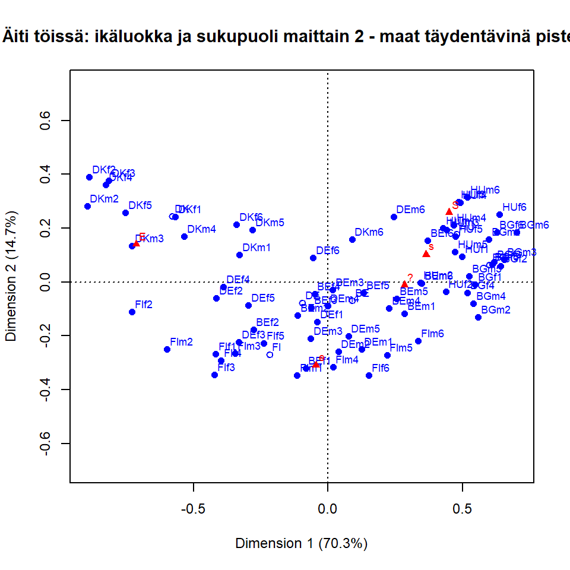

```r
plot(spCAmaaga1, main = "Äiti töissä: ikäluokka ja sukupuoli maittain 2 - maat täydentävinä pisteinä"
                    )
```

```r
#par()

#asymmetrinen kartta
#X11()
#par("cex"= 0.75, "asp" = 1, "offset" = 0.5)
#plot(spCAmaaga1, main = "Äiti töissä: ikäluokka ja sukupuoli maittain 3 (kontribuutiot) - liian tukkoinen kuva",
#                  map = "rowgreen",
#                  contrib= c("absolute", "absolute"),
#                  mass = c(TRUE,TRUE),
#                  arrows = c(FALSE,TRUE)
#                  )
#numeeriset tulokset
summary(spCAmaaga1)
```

```
##
## Principal inertias (eigenvalues):
##
##  dim    value      %   cum%   scree plot
##  1      0.184895  70.3  70.3  ******************
##  2      0.038751  14.7  85.0  ****
##  3      0.024006   9.1  94.1  **
##  4      0.015502   5.9 100.0  *
##         -------- -----
##  Total: 0.263154 100.0
##
##
## Rows:
##       name   mass  qlt  inr    k=1 cor  ctr    k=2 cor  ctr
## 1  |  BEf1 |   14  678    9 |  -83  43    1 | -320 635   38 |
```

[output cut: 85 more lines]

Kartan herkkyyttä joillekin pienen massan rivipisteille pitää tutkia tarkemmin.

Vertailu voi tehdä

1. maiden sisällä, ikä-sukupuoli - luokkien välillä. Ovatko naiset kaikissa ikäluokissa mies-ikäluokkien oikealla vai vasemmalla puolella?
2. maiden välillä
1. miten ikä-sukupuoliluokat sijaitsevat suhteessa maiden keskiarvopisteisiin
2. mikä on niiden järjestys

# 5 Yksinkertaisen korrespondenssianalyysin laajennuksia 2

**ZXY** Tässä laajennetaan data isommaksi aineistoksi, lisää maita.

```r
#valittavien maiden kolminumeroinen ISO 3166 - koodi vektoriin - TÄSSÄ KAIKKI MAAT (27, ei Espanjaa)
#incl_countriesALL <- c(36, 40, 56,100, 124, 191, 203, 208, 246, 250, 276, 348, 352, 372, 428, 440,
#                    528, 578, 616, 620, 643, 703, 705, 752, 756, 826, 840)
#ISSP2012.data <- read_spss("data/ZA5900_v4-0-0.sav") # (user_na = TRUE pois 27.9.18)
#
#str(ISSP2012.data) #61754 obs. of  420 variables
#ISSP2012jh1.data <- filter(ISSP2012.data, V4 %in% incl_countriesALL)
#
```

## 5.1 Päällekkäiset matriisit (stacked matices)

Ref:CAip, CA_Week2.pdf (kalvot MCA-kurssilta 2017)

Concatenated tables (yhdistetyt taulut tai matriisit): (a) kaksi luokittelumuuttujaa (b) useita muuttujia stacked (“pinotaan”).

MCA 2017 laskareissa ja kalvoissa esitetään, miten nämä saadaan kätevästi CA-paketin MJCA-funktion BURT-optiolla.

## 5.2 Matched matrices

Ref:CAip ss. 177, HY2017_MCA, Greenacre JAS 2013 (sovellus ISSP 1989, 4 kysymystä ‘pitäisikö äidin olla kotona’, 8 maata), tässä artikkelissa “SVD-based methods”, joista yksi CA (muut biplots, PCA, compositional data/log ratios).

Edellisen menetelmän variantti, jossa ryhmien väliset ja sisäiset erot saadaan esiin. Inertian jakaminen. Samanlaisten rivien ja sarakkeiden kaksi samankokoista taulua, esimerkiksi sukupuolivaikutusten arviointi. Alkuperäinen taulukko jaetaan kahdeksi tauluksi sukupuolen mukaan. Matriisien yhdistäminen (concatenation) riveittäin tai sarakkeittain ei näytä optimaalisesti mm - matriisien eroja.

Ryhmien välisen ja ryhmien sisäinen inertian erottaminen, **ABBA** on yksi ratkaisu (ABBA matrix, teknisesti block circulanMat matrix).

Luokittelu voi olla myös kahden indikaattorimuuttujan avulla jako neljään taulukkoon (esim. miehet vs. naiset länsieuroopassa verratuna samaan asetelmaan itä-Euroopassa). Samaa ideaa laajennetaan.

Esimerkkinä “Attitudes to women working in 2012”.